# Dietary intake, Nutritional status, and Health outcomes among Vegan, Vegetarian and Omnivore families: results from the observational study

- Show All Code
- Hide All Code
- View Source

Statistical report - diet prediction (elastic net)

**Authors and affiliations**

Marina Heniková<sup>1,2</sup>, Anna Ouřadová<sup>1</sup>, Eliška Selinger<sup>1,3</sup>, Filip Tichanek<sup>4</sup>, Petra Polakovičová<sup>4</sup>, Dana Hrnčířová<sup>2</sup>, Pavel Dlouhý<sup>2</sup>, Martin Světnička<sup>5</sup>, Eva El-Lababidi<sup>5</sup>, Jana Potočková<sup>1</sup>, Tilman Kühn<sup>6</sup>, Monika Cahová<sup>4</sup>, Jan Gojda<sup>1</sup>

<sup>1</sup> Department of Internal Medicine, Kralovske Vinohrady University Hospital and Third Faculty of Medicine, Charles University, Prague, Czech Republic.  
<sup>2</sup> Department of Hygiene, Third Faculty of Medicine, Charles University, Prague, Czech Republic.  
<sup>3</sup> National Health Institute, Prague, Czech Republic.  
<sup>4</sup> Institute for Clinical and Experimental Medicine, Prague, Czech Republic.  
<sup>5</sup> Department of Pediatrics, Kralovske Vinohrady University Hospital and Third Faculty of Medicine, Charles University, Prague, Czech Republic.  
<sup>6</sup> Department of Epidemiology, MedUni, Vienna, Austria.

This is a statistical report of the study currenlty *under review* in the [*Communications Medicine*](https://www.nature.com/commsmed) journal.

Original [GitHub repository](https://github.com/filip-tichanek/kompas_clinical): https://github.com/filip-tichanek/kompas_clinical

Statistical **reports** can be found on the [reports hub](https://filip-tichanek.github.io/kompas_clinical/).

Data analysis is described in detail in the [statistical methods](https://filip-tichanek.github.io/kompas_clinical/html/368_G_Methods.html) report.

# 1 Introduction

This project is designed to evaluate and compare clinical outcomes across three distinct dietary strategy groups:

- Vegans
- Vegetarians
- Omnivores

The dataset includes both adults and children, with data clustered within families.

## 1.1 Main Questions

The study addresses the following key questions:

Q1. Do clinical outcomes vary significantly across different diet strategies?

Q2. Beyond diet group, which factors (e.g., sex, age, breastfeeding status for children, or supplementation when applicable) most strongly influence clinical outcomes? How correlated (“clustered”) are these characteristics within the same family?

Q3. Could the clinical characteristics effectively discriminate between different diet groups?

## 1.2 Statistical Methods

For full methodological details, see [this report](https://filip-tichanek.github.io/kompas_clinical/html/368_G_Methods.html). In brief:

- **Robust linear mixed-effects models (rLME)** were used to estimate adjusted differences between diet groups (Q1) and assess the importance of other variables (Q2), including how much clinical characteristics tend to cluster within families. Covariates included age, sex, breastfeeding status for children, and relevant supplementation factors where applicable.
- **Elastic net logistic regression** was employed to answer Q3, evaluating whether clinical characteristics provide a strong overall signal distinguishing between diet groups, incorporating a predictive perspective.

All analyses were conducted separately for adults and children.

**Open code**

```r
# Import initiation file
source('r/368_initiation.R')
```

# 2 Data wrangling

## 2.1 All children

**Open code**

```r
skimr::skim(dat_child_all)
```

Data summary

| Name | dat_child_all |
| --- | --- |
| Number of rows | 142 |
| Number of columns | 75 |
| _______________________ |  |
| Column type frequency: |  |
| factor | 4 |
| numeric | 71 |
| ________________________ |  |
| Group variables | None |

**Variable type: factor**

| skim_variable | n_missing | complete_rate | ordered | n_unique | top_counts |
| --- | --- | --- | --- | --- | --- |
| ID | 0 | 1 | FALSE | 142 | K10: 1, K10: 1, K10: 1, K11: 1 |
| FAM | 0 | 1 | FALSE | 95 | R25: 3, R41: 3, R55: 3, R70: 3 |
| SEX | 0 | 1 | FALSE | 2 | F: 73, M: 69 |
| GRP | 0 | 1 | FALSE | 3 | VN: 61, OM: 44, VG: 37 |

**Variable type: numeric**

| skim_variable | n_missing | complete_rate | mean | sd | p0 | p25 | p50 | p75 | p100 | hist |
| --- | --- | --- | --- | --- | --- | --- | --- | --- | --- | --- |
| aAGE | 0 | 1.00 | 3.34 | 2.46 | 0.18 | 1.34 | 2.74 | 4.88 | 12.04 | ▇▅▃▁▁ |
| aBreastFeed_full | 0 | 1.00 | 6.04 | 2.10 | 0.00 | 6.00 | 6.00 | 6.00 | 18.00 | ▁▇▁▁▁ |
| aBreastFeed_total | 13 | 0.91 | 15.90 | 10.14 | 0.00 | 9.21 | 14.00 | 19.00 | 60.00 | ▇▇▂▁▁ |
| aBreastFeed_full_stopped | 0 | 1.00 | 0.92 | 0.27 | 0.00 | 1.00 | 1.00 | 1.00 | 1.00 | ▁▁▁▁▇ |
| aBreastFeed_total_stopped | 0 | 1.00 | 0.68 | 0.47 | 0.00 | 0.00 | 1.00 | 1.00 | 1.00 | ▃▁▁▁▇ |
| dev_delay | 0 | 1.00 | 0.02 | 0.14 | 0.00 | 0.00 | 0.00 | 0.00 | 1.00 | ▇▁▁▁▁ |
| aMASS_Perc | 0 | 1.00 | 46.85 | 28.80 | 0.00 | 21.00 | 49.00 | 68.50 | 99.00 | ▇▆▃▇▅ |
| aHEIGHT_Perc | 0 | 1.00 | 45.35 | 27.47 | 0.00 | 19.50 | 44.00 | 68.75 | 100.00 | ▇▇▅▇▃ |
| aBMI_PERC | 0 | 1.00 | 50.50 | 24.96 | 0.00 | 34.25 | 50.00 | 68.00 | 100.00 | ▃▅▇▅▃ |
| aM_per_H_PERC | 0 | 1.00 | 49.98 | 24.85 | 0.00 | 33.00 | 51.00 | 66.75 | 99.00 | ▃▃▇▆▃ |
| aGLY | 10 | 0.93 | 4.45 | 0.59 | 3.26 | 4.16 | 4.42 | 4.72 | 7.49 | ▂▇▁▁▁ |
| aTC | 10 | 0.93 | 3.78 | 0.66 | 2.21 | 3.30 | 3.87 | 4.21 | 5.56 | ▂▆▇▅▁ |
| aHDL | 10 | 0.93 | 1.26 | 0.33 | 0.66 | 1.01 | 1.25 | 1.42 | 2.16 | ▆▇▇▂▂ |
| aLDL | 10 | 0.93 | 2.05 | 0.57 | 0.24 | 1.69 | 2.02 | 2.41 | 3.48 | ▁▃▇▆▂ |
| aTG | 10 | 0.93 | 1.06 | 0.60 | 0.30 | 0.66 | 0.92 | 1.22 | 3.57 | ▇▅▁▁▁ |
| aCa | 9 | 0.94 | 2.57 | 0.12 | 2.35 | 2.48 | 2.56 | 2.65 | 2.88 | ▃▇▆▅▁ |
| aP | 9 | 0.94 | 1.66 | 0.18 | 1.30 | 1.54 | 1.67 | 1.79 | 2.10 | ▃▆▇▅▁ |
| aMg | 9 | 0.94 | 0.86 | 0.07 | 0.71 | 0.81 | 0.85 | 0.90 | 1.17 | ▃▇▃▁▁ |
| aSe | 11 | 0.92 | 0.79 | 0.28 | 0.27 | 0.60 | 0.77 | 0.94 | 2.02 | ▅▇▃▁▁ |
| aZn | 11 | 0.92 | 11.56 | 2.41 | 7.00 | 10.15 | 11.30 | 12.80 | 21.30 | ▃▇▃▁▁ |
| aFE | 9 | 0.94 | 13.37 | 6.94 | 1.60 | 8.30 | 12.60 | 17.80 | 32.70 | ▆▇▇▂▁ |
| aVKFE | 10 | 0.93 | 71.66 | 9.12 | 48.00 | 66.00 | 72.00 | 77.00 | 103.00 | ▂▆▇▂▁ |
| aFERR | 9 | 0.94 | 18.62 | 15.03 | 3.10 | 10.40 | 15.20 | 21.70 | 133.70 | ▇▁▁▁▁ |
| aTRF | 9 | 0.94 | 2.84 | 0.36 | 1.90 | 2.60 | 2.85 | 3.05 | 4.10 | ▂▆▇▂▁ |
| aSATTRF | 9 | 0.94 | 18.90 | 9.89 | 2.10 | 11.60 | 18.10 | 24.90 | 43.70 | ▅▇▆▂▂ |
| aTRFINDEX | 9 | 0.94 | 1.55 | 0.74 | 0.59 | 1.13 | 1.38 | 1.70 | 5.41 | ▇▃▁▁▁ |
| aSTRF | 9 | 0.94 | 1.67 | 0.33 | 1.08 | 1.43 | 1.62 | 1.81 | 2.98 | ▅▇▂▁▁ |
| aHGB | 14 | 0.90 | 121.94 | 9.48 | 99.00 | 115.00 | 121.00 | 127.25 | 157.00 | ▁▇▆▂▁ |
| aMCV | 14 | 0.90 | 78.81 | 3.83 | 68.20 | 76.77 | 79.45 | 81.10 | 88.30 | ▂▃▇▇▁ |
| aPTH | 10 | 0.93 | 2.88 | 1.25 | 0.70 | 1.90 | 2.80 | 3.60 | 7.80 | ▆▇▃▁▁ |
| aCros | 11 | 0.92 | 1.26 | 0.31 | 0.57 | 1.08 | 1.23 | 1.42 | 2.71 | ▃▇▃▁▁ |
| aP1NP | 11 | 0.92 | 720.87 | 294.64 | 215.00 | 482.00 | 631.00 | 959.50 | 1200.99 | ▂▇▅▂▅ |
| aUI | 30 | 0.79 | 176.10 | 142.86 | 6.00 | 86.95 | 138.00 | 228.50 | 911.00 | ▇▃▁▁▁ |
| aUREA | 9 | 0.94 | 4.21 | 1.24 | 1.80 | 3.40 | 4.20 | 5.10 | 7.70 | ▅▇▇▃▁ |
| aCREA | 9 | 0.94 | 25.99 | 7.50 | 15.00 | 20.00 | 25.00 | 31.00 | 51.00 | ▇▅▅▁▁ |
| aUA | 9 | 0.94 | 226.97 | 48.32 | 78.00 | 197.00 | 224.00 | 257.00 | 391.00 | ▁▅▇▃▁ |
| aVIT_AKTB12 | 11 | 0.92 | 127.83 | 82.79 | 31.50 | 77.75 | 108.70 | 144.05 | 493.90 | ▇▃▁▁▁ |
| aHCY | 23 | 0.84 | 8.69 | 3.09 | 3.90 | 6.85 | 8.10 | 9.75 | 25.80 | ▇▆▁▁▁ |
| aMMA | 19 | 0.87 | 286.37 | 354.72 | 67.30 | 148.95 | 187.70 | 258.25 | 2980.40 | ▇▁▁▁▁ |
| aVIT_D | 9 | 0.94 | 92.73 | 30.42 | 36.90 | 69.80 | 87.60 | 110.20 | 194.20 | ▅▇▅▂▁ |
| aFOLAT | 10 | 0.93 | 16.41 | 4.66 | 4.50 | 13.05 | 16.90 | 19.65 | 24.04 | ▁▅▇▇▆ |
| aIGF1 | 20 | 0.86 | 110.37 | 63.87 | 24.60 | 63.60 | 92.35 | 136.98 | 318.00 | ▇▆▃▁▁ |
| aUr_Ca | 18 | 0.87 | 1.55 | 1.55 | 0.25 | 0.37 | 1.02 | 2.26 | 7.41 | ▇▂▁▁▁ |
| aCa_per_Krea | 18 | 0.87 | 0.48 | 0.51 | 0.03 | 0.12 | 0.31 | 0.64 | 2.75 | ▇▂▁▁▁ |
| aI_per_Krea | 31 | 0.78 | 553.90 | 748.54 | 60.27 | 189.31 | 351.80 | 563.53 | 5887.55 | ▇▁▁▁▁ |
| aP_per_Krea | 18 | 0.87 | 3.54 | 2.13 | 0.14 | 1.71 | 3.14 | 4.73 | 9.24 | ▇▇▆▂▂ |
| aAL_child | 0 | 1.00 | 0.12 | 0.33 | 0.00 | 0.00 | 0.00 | 0.00 | 1.00 | ▇▁▁▁▁ |
| aBREAKS | 0 | 1.00 | 0.04 | 0.18 | 0.00 | 0.00 | 0.00 | 0.00 | 1.00 | ▇▁▁▁▁ |
| aSUP_VEG1 | 0 | 1.00 | 0.05 | 0.22 | 0.00 | 0.00 | 0.00 | 0.00 | 1.00 | ▇▁▁▁▁ |
| aSup_B12 | 0 | 1.00 | 0.50 | 0.50 | 0.00 | 0.00 | 0.50 | 1.00 | 1.00 | ▇▁▁▁▇ |
| aSUP_FOL | 0 | 1.00 | 0.04 | 0.18 | 0.00 | 0.00 | 0.00 | 0.00 | 1.00 | ▇▁▁▁▁ |
| aSUP_vitA | 0 | 1.00 | 0.01 | 0.12 | 0.00 | 0.00 | 0.00 | 0.00 | 1.00 | ▇▁▁▁▁ |
| aSUP_vitB1 | 0 | 1.00 | 0.04 | 0.18 | 0.00 | 0.00 | 0.00 | 0.00 | 1.00 | ▇▁▁▁▁ |
| aSUP_vit.B5 | 0 | 1.00 | 0.04 | 0.18 | 0.00 | 0.00 | 0.00 | 0.00 | 1.00 | ▇▁▁▁▁ |
| aSUP_D | 0 | 1.00 | 0.72 | 0.45 | 0.00 | 0.00 | 1.00 | 1.00 | 1.00 | ▃▁▁▁▇ |
| aSUP_Mg | 0 | 1.00 | 0.05 | 0.22 | 0.00 | 0.00 | 0.00 | 0.00 | 1.00 | ▇▁▁▁▁ |
| aSUP_Zn | 0 | 1.00 | 0.04 | 0.18 | 0.00 | 0.00 | 0.00 | 0.00 | 1.00 | ▇▁▁▁▁ |
| aSUP_Se | 0 | 1.00 | 0.02 | 0.14 | 0.00 | 0.00 | 0.00 | 0.00 | 1.00 | ▇▁▁▁▁ |
| aSUP_Ca | 0 | 1.00 | 0.04 | 0.18 | 0.00 | 0.00 | 0.00 | 0.00 | 1.00 | ▇▁▁▁▁ |
| aSUP_Fe | 0 | 1.00 | 0.07 | 0.26 | 0.00 | 0.00 | 0.00 | 0.00 | 1.00 | ▇▁▁▁▁ |
| aSUP_Iod | 0 | 1.00 | 0.06 | 0.24 | 0.00 | 0.00 | 0.00 | 0.00 | 1.00 | ▇▁▁▁▁ |
| aSUP_Ѡ3 | 0 | 1.00 | 0.40 | 0.49 | 0.00 | 0.00 | 0.00 | 1.00 | 1.00 | ▇▁▁▁▆ |
| aSUP_CHLO | 0 | 1.00 | 0.02 | 0.14 | 0.00 | 0.00 | 0.00 | 0.00 | 1.00 | ▇▁▁▁▁ |
| aSUP_ALG | 0 | 1.00 | 0.00 | 0.00 | 0.00 | 0.00 | 0.00 | 0.00 | 0.00 | ▁▁▇▁▁ |
| aSUP_GB | 0 | 1.00 | 0.01 | 0.08 | 0.00 | 0.00 | 0.00 | 0.00 | 1.00 | ▇▁▁▁▁ |
| aSUP_FORT | 0 | 1.00 | 0.01 | 0.08 | 0.00 | 0.00 | 0.00 | 0.00 | 1.00 | ▇▁▁▁▁ |
| aSUP_PROB | 0 | 1.00 | 0.06 | 0.24 | 0.00 | 0.00 | 0.00 | 0.00 | 1.00 | ▇▁▁▁▁ |
| aSUP_OTH | 0 | 1.00 | 0.21 | 0.41 | 0.00 | 0.00 | 0.00 | 0.00 | 1.00 | ▇▁▁▁▂ |
| aBiW | 2 | 0.99 | 3336.26 | 541.50 | 2000.00 | 3047.50 | 3400.00 | 3657.50 | 5000.00 | ▂▅▇▃▁ |
| log2_age | 0 | 1.00 | 1.29 | 1.25 | -2.49 | 0.43 | 1.45 | 2.29 | 3.59 | ▁▃▆▇▅ |
| aBreastFeed_full_duration | 0 | 1.00 | 5.64 | 2.61 | 0.00 | 5.50 | 6.00 | 6.00 | 18.00 | ▁▇▁▁▁ |

### 2.1.1 Wrangle data

**Open code**

```r
for (i in 1:ncol(dat_child_all)) {
  names(dat_child_all)[i] <- str_replace_all(
    names(dat_child_all)[i], c("^a" = "")
  )
}

dat_child_all <- dat_child_all %>%
  rename(
    FOLATE = FOLAT,
    TIBC = VKFE,
    HOLOTC = VIT_AKTB12,
    CTX = Cros,
    uCCR = Ca_per_Krea,
    uICR = I_per_Krea,
    uPCR = P_per_Krea,
    uCa = Ur_Ca
    ) %>%
  mutate(
    log2_TG = log2(TG),
    log2_Se = log2(Se),
    log2_Zn = log2(Zn),
    log2_FERR = log2(FERR),
    log2_TRFINDEX = log2(TRFINDEX),
    log2_STRF = log2(STRF),
    log2_CTX = log2(CTX),
    log2_UI = log2(UI),
    log2_CREA = log2(CREA),
    log2_HOLOTC = log2(HOLOTC),
    log2_HCY = log2(HCY),
    log2_MMA = log2(MMA),
    log2_VIT_D = log2(VIT_D),
    log2_IGF1 = log2(IGF1),
    log2_uCa = log2(uCa),
    log2_uCCR = log2(uCCR),
    log2_uICR = log2(uICR)
    ) %>%
  mutate(
    male = if_else(SEX == "M", 1, 0),
    GRP = factor(GRP),
    FAM = factor(FAM)
  ) %>%
  select(

    ## remove irrelevant variables not included to any inference and prediction
    -c(SEX, BreastFeed_full, BreastFeed_total, ID, dev_delay, BREAKS, AGE),

    ## remove information about supplementation
    -c(SUP_VEG1:SUP_OTH),

    ## remove non-log2-transformed version when log2(variable) is included
    -c(TG, Se, Zn, FERR, TRFINDEX,
       STRF, CTX, UI, CREA, HOLOTC, HCY,
       MMA, VIT_D, IGF1, uCa, uCCR, uICR
       )
    ) %>%
  select(FAM, GRP, log2_age, male, BiW,
         BreastFeed_full_duration, BreastFeed_full_stopped, BreastFeed_total_stopped,
         everything()
         )
```

### 2.1.2 Missing values and standardization

**Open code**

```r
skimr::skim(dat_child_all)
```

Data summary

| Name | dat_child_all |
| --- | --- |
| Number of rows | 142 |
| Number of columns | 49 |
| _______________________ |  |
| Column type frequency: |  |
| factor | 2 |
| numeric | 47 |
| ________________________ |  |
| Group variables | None |

**Variable type: factor**

| skim_variable | n_missing | complete_rate | ordered | n_unique | top_counts |
| --- | --- | --- | --- | --- | --- |
| FAM | 0 | 1 | FALSE | 95 | R25: 3, R41: 3, R55: 3, R70: 3 |
| GRP | 0 | 1 | FALSE | 3 | VN: 61, OM: 44, VG: 37 |

**Variable type: numeric**

| skim_variable | n_missing | complete_rate | mean | sd | p0 | p25 | p50 | p75 | p100 | hist |
| --- | --- | --- | --- | --- | --- | --- | --- | --- | --- | --- |
| log2_age | 0 | 1.00 | 1.29 | 1.25 | -2.49 | 0.43 | 1.45 | 2.29 | 3.59 | ▁▃▆▇▅ |
| male | 0 | 1.00 | 0.49 | 0.50 | 0.00 | 0.00 | 0.00 | 1.00 | 1.00 | ▇▁▁▁▇ |
| BiW | 2 | 0.99 | 3336.26 | 541.50 | 2000.00 | 3047.50 | 3400.00 | 3657.50 | 5000.00 | ▂▅▇▃▁ |
| BreastFeed_full_duration | 0 | 1.00 | 5.64 | 2.61 | 0.00 | 5.50 | 6.00 | 6.00 | 18.00 | ▁▇▁▁▁ |
| BreastFeed_full_stopped | 0 | 1.00 | 0.92 | 0.27 | 0.00 | 1.00 | 1.00 | 1.00 | 1.00 | ▁▁▁▁▇ |
| BreastFeed_total_stopped | 0 | 1.00 | 0.68 | 0.47 | 0.00 | 0.00 | 1.00 | 1.00 | 1.00 | ▃▁▁▁▇ |
| MASS_Perc | 0 | 1.00 | 46.85 | 28.80 | 0.00 | 21.00 | 49.00 | 68.50 | 99.00 | ▇▆▃▇▅ |
| HEIGHT_Perc | 0 | 1.00 | 45.35 | 27.47 | 0.00 | 19.50 | 44.00 | 68.75 | 100.00 | ▇▇▅▇▃ |
| BMI_PERC | 0 | 1.00 | 50.50 | 24.96 | 0.00 | 34.25 | 50.00 | 68.00 | 100.00 | ▃▅▇▅▃ |
| M_per_H_PERC | 0 | 1.00 | 49.98 | 24.85 | 0.00 | 33.00 | 51.00 | 66.75 | 99.00 | ▃▃▇▆▃ |
| GLY | 10 | 0.93 | 4.45 | 0.59 | 3.26 | 4.16 | 4.42 | 4.72 | 7.49 | ▂▇▁▁▁ |
| TC | 10 | 0.93 | 3.78 | 0.66 | 2.21 | 3.30 | 3.87 | 4.21 | 5.56 | ▂▆▇▅▁ |
| HDL | 10 | 0.93 | 1.26 | 0.33 | 0.66 | 1.01 | 1.25 | 1.42 | 2.16 | ▆▇▇▂▂ |
| LDL | 10 | 0.93 | 2.05 | 0.57 | 0.24 | 1.69 | 2.02 | 2.41 | 3.48 | ▁▃▇▆▂ |
| Ca | 9 | 0.94 | 2.57 | 0.12 | 2.35 | 2.48 | 2.56 | 2.65 | 2.88 | ▃▇▆▅▁ |
| P | 9 | 0.94 | 1.66 | 0.18 | 1.30 | 1.54 | 1.67 | 1.79 | 2.10 | ▃▆▇▅▁ |
| Mg | 9 | 0.94 | 0.86 | 0.07 | 0.71 | 0.81 | 0.85 | 0.90 | 1.17 | ▃▇▃▁▁ |
| FE | 9 | 0.94 | 13.37 | 6.94 | 1.60 | 8.30 | 12.60 | 17.80 | 32.70 | ▆▇▇▂▁ |
| TIBC | 10 | 0.93 | 71.66 | 9.12 | 48.00 | 66.00 | 72.00 | 77.00 | 103.00 | ▂▆▇▂▁ |
| TRF | 9 | 0.94 | 2.84 | 0.36 | 1.90 | 2.60 | 2.85 | 3.05 | 4.10 | ▂▆▇▂▁ |
| SATTRF | 9 | 0.94 | 18.90 | 9.89 | 2.10 | 11.60 | 18.10 | 24.90 | 43.70 | ▅▇▆▂▂ |
| HGB | 14 | 0.90 | 121.94 | 9.48 | 99.00 | 115.00 | 121.00 | 127.25 | 157.00 | ▁▇▆▂▁ |
| MCV | 14 | 0.90 | 78.81 | 3.83 | 68.20 | 76.77 | 79.45 | 81.10 | 88.30 | ▂▃▇▇▁ |
| PTH | 10 | 0.93 | 2.88 | 1.25 | 0.70 | 1.90 | 2.80 | 3.60 | 7.80 | ▆▇▃▁▁ |
| P1NP | 11 | 0.92 | 720.87 | 294.64 | 215.00 | 482.00 | 631.00 | 959.50 | 1200.99 | ▂▇▅▂▅ |
| UREA | 9 | 0.94 | 4.21 | 1.24 | 1.80 | 3.40 | 4.20 | 5.10 | 7.70 | ▅▇▇▃▁ |
| UA | 9 | 0.94 | 226.97 | 48.32 | 78.00 | 197.00 | 224.00 | 257.00 | 391.00 | ▁▅▇▃▁ |
| FOLATE | 10 | 0.93 | 16.41 | 4.66 | 4.50 | 13.05 | 16.90 | 19.65 | 24.04 | ▁▅▇▇▆ |
| uPCR | 18 | 0.87 | 3.54 | 2.13 | 0.14 | 1.71 | 3.14 | 4.73 | 9.24 | ▇▇▆▂▂ |
| AL_child | 0 | 1.00 | 0.12 | 0.33 | 0.00 | 0.00 | 0.00 | 0.00 | 1.00 | ▇▁▁▁▁ |
| log2_TG | 10 | 0.93 | -0.10 | 0.71 | -1.74 | -0.60 | -0.12 | 0.29 | 1.84 | ▂▆▇▃▁ |
| log2_Se | 11 | 0.92 | -0.43 | 0.51 | -1.89 | -0.74 | -0.38 | -0.10 | 1.01 | ▁▃▇▅▁ |
| log2_Zn | 11 | 0.92 | 3.50 | 0.29 | 2.81 | 3.34 | 3.50 | 3.68 | 4.41 | ▂▆▇▂▁ |
| log2_FERR | 9 | 0.94 | 3.92 | 0.90 | 1.63 | 3.38 | 3.93 | 4.44 | 7.06 | ▂▆▇▂▁ |
| log2_TRFINDEX | 9 | 0.94 | 0.52 | 0.54 | -0.76 | 0.18 | 0.46 | 0.77 | 2.44 | ▂▇▆▁▁ |
| log2_STRF | 9 | 0.94 | 0.72 | 0.27 | 0.11 | 0.52 | 0.70 | 0.86 | 1.58 | ▂▇▇▂▁ |
| log2_CTX | 11 | 0.92 | 0.29 | 0.36 | -0.81 | 0.11 | 0.30 | 0.50 | 1.44 | ▁▃▇▃▁ |
| log2_UI | 30 | 0.79 | 7.03 | 1.25 | 2.58 | 6.44 | 7.11 | 7.84 | 9.83 | ▁▁▆▇▂ |
| log2_CREA | 9 | 0.94 | 4.64 | 0.40 | 3.91 | 4.32 | 4.64 | 4.95 | 5.67 | ▇▇▇▆▁ |
| log2_HOLOTC | 11 | 0.92 | 6.76 | 0.81 | 4.98 | 6.28 | 6.76 | 7.17 | 8.95 | ▂▆▇▃▁ |
| log2_HCY | 23 | 0.84 | 3.05 | 0.45 | 1.96 | 2.78 | 3.02 | 3.29 | 4.69 | ▁▇▆▁▁ |
| log2_MMA | 19 | 0.87 | 7.75 | 0.91 | 6.07 | 7.22 | 7.55 | 8.01 | 11.54 | ▂▇▁▁▁ |
| log2_VIT_D | 9 | 0.94 | 6.46 | 0.46 | 5.21 | 6.13 | 6.45 | 6.78 | 7.60 | ▁▅▇▅▁ |
| log2_IGF1 | 20 | 0.86 | 6.56 | 0.83 | 4.62 | 5.99 | 6.53 | 7.10 | 8.31 | ▂▆▇▇▃ |
| log2_uCa | 18 | 0.87 | -0.06 | 1.47 | -2.00 | -1.43 | 0.04 | 1.18 | 2.89 | ▇▅▅▆▂ |
| log2_uCCR | 18 | 0.87 | -1.78 | 1.50 | -5.14 | -3.00 | -1.68 | -0.65 | 1.46 | ▂▆▇▆▂ |
| log2_uICR | 31 | 0.78 | 8.46 | 1.28 | 5.91 | 7.56 | 8.46 | 9.14 | 12.52 | ▃▇▇▂▁ |

Removing features with over 25% NA values: all variables are below this threshold, no will be excluded

#### 2.1.2.1 Multiple imputation

Prepare

**Open code**

```r
dat_child_all_toimp <- dat_child_all %>% select(-FAM)

init <- mice(dat_child_all_toimp, maxit = 0)
init$method
##                      GRP                 log2_age                     male
##                       ""                       ""                       ""
##                      BiW BreastFeed_full_duration  BreastFeed_full_stopped
##                    "pmm"                       ""                       ""
## BreastFeed_total_stopped                MASS_Perc              HEIGHT_Perc
##                       ""                       ""                       ""
##                 BMI_PERC             M_per_H_PERC                      GLY
##                       ""                       ""                    "pmm"
##                       TC                      HDL                      LDL
##                    "pmm"                    "pmm"                    "pmm"
##                       Ca                        P                       Mg
##                    "pmm"                    "pmm"                    "pmm"
##                       FE                     TIBC                      TRF
##                    "pmm"                    "pmm"                    "pmm"
##                   SATTRF                      HGB                      MCV
##                    "pmm"                    "pmm"                    "pmm"
##                      PTH                     P1NP                     UREA
##                    "pmm"                    "pmm"                    "pmm"
##                       UA                   FOLATE                     uPCR
##                    "pmm"                    "pmm"                    "pmm"
##                 AL_child                  log2_TG                  log2_Se
##                       ""                    "pmm"                    "pmm"
##                  log2_Zn                log2_FERR            log2_TRFINDEX
##                    "pmm"                    "pmm"                    "pmm"
##                log2_STRF                 log2_CTX                  log2_UI
##                    "pmm"                    "pmm"                    "pmm"
##                log2_CREA              log2_HOLOTC                 log2_HCY
##                    "pmm"                    "pmm"                    "pmm"
##                 log2_MMA               log2_VIT_D                log2_IGF1
##                    "pmm"                    "pmm"                    "pmm"
##                 log2_uCa                log2_uCCR                log2_uICR
##                    "pmm"                    "pmm"                    "pmm"

data_imputed <- run(
  expr = mice(
    dat_child_all_toimp,
    method = init$method,
    m = 1
  ),
  path = "gitignore/run/data_child_all_imputed"
)

dat_child_all_imputed <- data.frame(
  FAM = dat_child_all$FAM,
  complete(data_imputed, 'all')[1]$`1`
  )
```

#### 2.1.2.2 Rescaling

**Open code**

```r
dat_child_all_imputed <- dat_child_all_imputed %>%
  mutate(
    across(
      where(~ is.numeric(.) && length(unique(.)) > 2),
      arm::rescale
    )
  )

summary(dat_child_all_imputed)
##       FAM      GRP        log2_age             male             BiW
##  R25    :  3   OM:44   Min.   :-1.51597   Min.   :0.0000   Min.   :-1.24365
##  R41    :  3   VG:37   1st Qu.:-0.34675   1st Qu.:0.0000   1st Qu.:-0.26830
##  R55    :  3   VN:61   Median : 0.06553   Median :0.0000   Median : 0.06022
##  R70    :  3           Mean   : 0.00000   Mean   :0.4859   Mean   : 0.00000
##  R91    :  3           3rd Qu.: 0.39903   3rd Qu.:1.0000   3rd Qu.: 0.30846
##  R11    :  2           Max.   : 0.92159   Max.   :1.0000   Max.   : 1.54041
##  (Other):125
##  BreastFeed_full_duration BreastFeed_full_stopped BreastFeed_total_stopped
##  Min.   :-1.08165         Min.   :0.0000          Min.   :0.0000
##  1st Qu.:-0.02701         1st Qu.:1.0000          1st Qu.:0.0000
##  Median : 0.06887         Median :1.0000          Median :1.0000
##  Mean   : 0.00000         Mean   :0.9225          Mean   :0.6761
##  3rd Qu.: 0.06887         3rd Qu.:1.0000          3rd Qu.:1.0000
##  Max.   : 2.36990         Max.   :1.0000          Max.   :1.0000
##
##    MASS_Perc         HEIGHT_Perc          BMI_PERC         M_per_H_PERC
##  Min.   :-0.81336   Min.   :-0.82527   Min.   :-1.01169   Min.   :-1.00579
##  1st Qu.:-0.44880   1st Qu.:-0.47038   1st Qu.:-0.32554   1st Qu.:-0.34169
##  Median : 0.03729   Median :-0.02448   Median :-0.01002   Median : 0.02055
##  Mean   : 0.00000   Mean   : 0.00000   Mean   : 0.00000   Mean   : 0.00000
##  3rd Qu.: 0.37581   3rd Qu.: 0.42597   3rd Qu.: 0.35058   3rd Qu.: 0.33751
##  Max.   : 0.90530   Max.   : 0.99471   Max.   : 0.99165   Max.   : 0.98652
##
##       GLY                 TC               HDL                 LDL
##  Min.   :-0.96932   Min.   :-1.1611   Min.   :-0.897027   Min.   :-1.5591
##  1st Qu.:-0.24605   1st Qu.:-0.3518   1st Qu.:-0.381160   1st Qu.:-0.3186
##  Median :-0.02522   Median : 0.0427   Median :-0.008379   Median :-0.0237
##  Mean   : 0.00000   Mean   : 0.0000   Mean   : 0.000000   Mean   : 0.0000
##  3rd Qu.: 0.23005   3rd Qu.: 0.3271   3rd Qu.: 0.274030   3rd Qu.: 0.3124
##  Max.   : 2.45859   Max.   : 1.2979   Max.   : 1.362247   Max.   : 1.2515
##
##        Ca                 P                  Mg                 FE
##  Min.   :-0.95206   Min.   :-1.04671   Min.   :-1.07088   Min.   :-0.85319
##  1st Qu.:-0.40979   1st Qu.:-0.35459   1st Qu.:-0.30075   1st Qu.:-0.36807
##  Median :-0.03437   Median : 0.02031   Median :-0.02071   Median :-0.05248
##  Mean   : 0.00000   Mean   : 0.00000   Mean   : 0.00000   Mean   : 0.00000
##  3rd Qu.: 0.34105   3rd Qu.: 0.36637   3rd Qu.: 0.31185   3rd Qu.: 0.33165
##  Max.   : 1.25874   Max.   : 1.26036   Max.   : 2.14964   Max.   : 1.39025
##
##       TIBC               TRF               SATTRF              HGB
##  Min.   :-1.28220   Min.   :-1.29718   Min.   :-0.86511   Min.   :-1.1969
##  1st Qu.:-0.33960   1st Qu.:-0.38031   1st Qu.:-0.37882   1st Qu.:-0.3516
##  Median : 0.02925   Median : 0.03263   Median :-0.04314   Median :-0.0346
##  Mean   : 0.00000   Mean   : 0.00000   Mean   : 0.00000   Mean   : 0.0000
##  3rd Qu.: 0.30246   3rd Qu.: 0.29859   3rd Qu.: 0.29509   3rd Qu.: 0.2824
##  Max.   : 1.72320   Max.   : 1.78238   Max.   : 1.25873   Max.   : 1.8674
##
##       MCV                PTH                P1NP              UREA
##  Min.   :-1.27228   Min.   :-0.86222   Min.   :-0.8720   Min.   :-0.95114
##  1st Qu.:-0.23179   1st Qu.:-0.37956   1st Qu.:-0.4112   1st Qu.:-0.33321
##  Median : 0.06504   Median :-0.03767   Median :-0.1493   Median :-0.01939
##  Mean   : 0.00000   Mean   : 0.00000   Mean   : 0.0000   Mean   : 0.00000
##  3rd Qu.: 0.29939   3rd Qu.: 0.30421   3rd Qu.: 0.5204   3rd Qu.: 0.34505
##  Max.   : 1.23989   Max.   : 1.99353   Max.   : 0.7624   Max.   : 1.43836
##
##        UA                 FOLATE              uPCR            AL_child
##  Min.   :-1.4333036   Min.   :-1.31482   Min.   :-0.7806   Min.   :0.0000
##  1st Qu.:-0.3100253   1st Qu.:-0.36494   1st Qu.:-0.4357   1st Qu.:0.0000
##  Median :-0.0000698   Median : 0.05861   Median :-0.1030   Median :0.0000
##  Mean   : 0.0000000   Mean   : 0.00000   Mean   : 0.0000   Mean   :0.1197
##  3rd Qu.: 0.3074059   3rd Qu.: 0.33510   3rd Qu.: 0.2779   3rd Qu.:0.0000
##  Max.   : 1.6712097   Max.   : 0.81004   Max.   : 1.2758   Max.   :1.0000
##
##     log2_TG            log2_Se            log2_Zn            log2_FERR
##  Min.   :-1.16637   Min.   :-1.44955   Min.   :-1.176518   Min.   :-1.223479
##  1st Qu.:-0.36102   1st Qu.:-0.30729   1st Qu.:-0.259301   1st Qu.:-0.309078
##  Median :-0.03236   Median : 0.04957   Median :-0.009786   Median : 0.002261
##  Mean   : 0.00000   Mean   : 0.00000   Mean   : 0.000000   Mean   : 0.000000
##  3rd Qu.: 0.27003   3rd Qu.: 0.33111   3rd Qu.: 0.322212   3rd Qu.: 0.291327
##  Max.   : 1.31588   Max.   : 1.42922   Max.   : 1.534604   Max.   : 1.684594
##
##  log2_TRFINDEX        log2_STRF           log2_CTX           log2_UI
##  Min.   :-1.17406   Min.   :-1.13215   Min.   :-1.48388   Min.   :-1.62194
##  1st Qu.:-0.31618   1st Qu.:-0.38289   1st Qu.:-0.26053   1st Qu.:-0.21541
##  Median :-0.05137   Median :-0.03349   Median : 0.03195   Median : 0.05194
##  Mean   : 0.00000   Mean   : 0.00000   Mean   : 0.00000   Mean   : 0.00000
##  3rd Qu.: 0.22979   3rd Qu.: 0.27543   3rd Qu.: 0.31093   3rd Qu.: 0.33609
##  Max.   : 1.74128   Max.   : 1.57692   Max.   : 1.58523   Max.   : 1.06570
##
##    log2_CREA        log2_HOLOTC         log2_HCY            log2_MMA
##  Min.   :-0.8901   Min.   :-1.0930   Min.   :-1.209351   Min.   :-0.9160
##  1st Qu.:-0.4414   1st Qu.:-0.2816   1st Qu.:-0.311324   1st Qu.:-0.3108
##  Median :-0.1205   Median : 0.0110   Median :-0.004265   Median :-0.1061
##  Mean   : 0.0000   Mean   : 0.0000   Mean   : 0.000000   Mean   : 0.0000
##  3rd Qu.: 0.4168   3rd Qu.: 0.2642   3rd Qu.: 0.236266   3rd Qu.: 0.1607
##  Max.   : 1.3131   Max.   : 1.3796   Max.   : 1.691373   Max.   : 1.9540
##
##    log2_VIT_D          log2_IGF1             log2_uCa          log2_uCCR
##  Min.   :-1.381056   Min.   :-1.0593846   Min.   :-0.67077   Min.   :-1.14730
##  1st Qu.:-0.366847   1st Qu.:-0.3340024   1st Qu.:-0.45358   1st Qu.:-0.41602
##  Median :-0.009946   Median :-0.0003994   Median : 0.03941   Median : 0.03259
##  Mean   : 0.000000   Mean   : 0.0000000   Mean   : 0.00000   Mean   : 0.00000
##  3rd Qu.: 0.342680   3rd Qu.: 0.3380598   3rd Qu.: 0.41488   3rd Qu.: 0.37986
##  Max.   : 1.233721   Max.   : 1.0670245   Max.   : 1.05893   Max.   : 1.09810
##
##    log2_uICR
##  Min.   :-0.99271
##  1st Qu.:-0.33192
##  Median :-0.01509
##  Mean   : 0.00000
##  3rd Qu.: 0.27115
##  Max.   : 1.59665
##
```

## 2.2 Adults

### 2.2.1 Wrangle data

**Open code**

```r
for (i in 1:ncol(dat_adult)) {
  names(dat_adult)[i] <- str_replace_all(
    names(dat_adult)[i], c("^a" = "")
  )
}


dat_adult <- dat_adult %>%
  rename(
    FOLATE = FOLAT,
    TIBC = VKFE,
    HOLOTC = VIT_AKTB12,
    CTX = Cros,
    uCCR = Ca_per_Krea,
    uICR = I_per_Krea,
    uPCR = P_per_Krea,
    uCa = Ur_Ca
  ) %>%
  mutate(
    log2_FAT = log2(FAT),
    log2_FFM = log2(FFM),
    log2_TC = log2(TC),
    log2_TG = log2(TG),
    log2_Se = log2(Se),
    log2_Zn = log2(Zn),
    log2_TIBC = log2(TIBC),
    log2_FERR = log2(FERR),
    log2_TRF = log2(TRF),
    log2_TRFINDEX = log2(TRFINDEX),
    log2_STRF = log2(STRF),
    log2_CTX = log2(CTX),
    log2_P1NP = log2(P1NP),
    log2_UI = log2(UI),
    log2_UREA = log2(UREA),
    log2_CREA = log2(CREA),
    log2_HOLOTC = log2(HOLOTC),
    log2_HCY = log2(HCY),
    log2_MMA = log2(MMA),
    log2_VIT_D = log2(VIT_D),
    log2_uCa = log2(uCa),
    log2_uCCR = log2(uCCR),
    log2_uICR = log2(uICR)
  ) %>%
  mutate(
    male = if_else(SEX == "M", 1, 0),
    GRP = factor(GRP),
    FAM = factor(FAM)
  ) %>%
  select(

    ## remove irrelevant variables not included to any inference and prediction
    -c(SEX, ID),

    ## remove information about supplementation
    -c(SUP_VEG1:SUP_OTH),

    ## remove non-log2-transformed version when log2(variable) is included
    -c(
      FAT, FFM, TC, TG, Se, Zn, TIBC, FERR, TRF, TRFINDEX, STRF,
      CTX, P1NP, UI, UREA, CREA, HOLOTC, HCY, MMA, VIT_D,
      uCa, uCCR, uICR
    )
  ) %>%
  select(
    FAM, GRP, AGE, male,
    everything()
  )

summary(dat_adult)
##       FAM      GRP          AGE             male            BMI
##  R1     :  2   OM:50   Min.   :21.54   Min.   :0.000   Min.   :15.89
##  R10    :  2   VG:45   1st Qu.:32.47   1st Qu.:0.000   1st Qu.:21.22
##  R11    :  2   VN:92   Median :35.32   Median :0.000   Median :23.49
##  R12    :  2           Mean   :35.54   Mean   :0.492   Mean   :23.85
##  R13    :  2           3rd Qu.:38.27   3rd Qu.:1.000   3rd Qu.:25.98
##  R14    :  2           Max.   :56.56   Max.   :1.000   Max.   :34.76
##  (Other):175
##       WHR             HEIGHT           MASS              HG
##  Min.   :0.6480   Min.   :1.531   Min.   : 46.80   Min.   :20.75
##  1st Qu.:0.7368   1st Qu.:1.690   1st Qu.: 62.60   1st Qu.:30.75
##  Median :0.7843   Median :1.742   Median : 70.40   Median :39.90
##  Mean   :0.7890   Mean   :1.747   Mean   : 73.09   Mean   :42.12
##  3rd Qu.:0.8341   3rd Qu.:1.804   3rd Qu.: 82.65   3rd Qu.:52.20
##  Max.   :1.0000   Max.   :1.983   Max.   :123.50   Max.   :76.25
##  NA's   :4                                         NA's   :1
##       PFAT            SBP             DBP              GLY
##  Min.   : 2.70   Min.   : 82.0   Min.   : 46.00   Min.   :3.100
##  1st Qu.:16.05   1st Qu.:112.5   1st Qu.: 71.00   1st Qu.:4.195
##  Median :21.90   Median :123.0   Median : 77.00   Median :4.460
##  Mean   :22.47   Mean   :124.2   Mean   : 76.86   Mean   :4.454
##  3rd Qu.:28.65   3rd Qu.:135.0   3rd Qu.: 83.00   3rd Qu.:4.720
##  Max.   :43.90   Max.   :179.0   Max.   :104.00   Max.   :8.410
##
##       HDL             LDL              Ca              P
##  Min.   :0.800   Min.   :1.070   Min.   :2.180   Min.   :0.660
##  1st Qu.:1.215   1st Qu.:2.020   1st Qu.:2.410   1st Qu.:1.005
##  Median :1.430   Median :2.440   Median :2.460   Median :1.100
##  Mean   :1.488   Mean   :2.538   Mean   :2.456   Mean   :1.108
##  3rd Qu.:1.710   3rd Qu.:2.965   3rd Qu.:2.510   3rd Qu.:1.220
##  Max.   :3.030   Max.   :5.960   Max.   :2.630   Max.   :1.480
##
##        Mg               FE            SATTRF           HGB
##  Min.   :0.6900   Min.   : 2.00   Min.   : 1.70   Min.   : 40.0
##  1st Qu.:0.7700   1st Qu.:14.75   1st Qu.:20.50   1st Qu.:135.5
##  Median :0.8100   Median :18.70   Median :27.30   Median :145.0
##  Mean   :0.8121   Mean   :20.04   Mean   :29.27   Mean   :144.0
##  3rd Qu.:0.8500   3rd Qu.:24.75   3rd Qu.:36.45   3rd Qu.:155.0
##  Max.   :1.0700   Max.   :46.70   Max.   :75.20   Max.   :182.0
##
##       MCV             PTH              UA            FOLATE
##  Min.   :57.60   Min.   :0.800   Min.   :138.0   Min.   : 3.05
##  1st Qu.:86.00   1st Qu.:2.400   1st Qu.:247.0   1st Qu.: 8.97
##  Median :88.40   Median :3.200   Median :296.0   Median :11.59
##  Mean   :88.61   Mean   :3.295   Mean   :301.7   Mean   :12.46
##  3rd Qu.:91.05   3rd Qu.:4.000   3rd Qu.:349.5   3rd Qu.:15.27
##  Max.   :99.50   Max.   :7.800   Max.   :516.0   Max.   :24.01
##
##       uPCR           AL_adult          BREAKS          log2_FAT
##  Min.   :0.1565   Min.   :0.0000   Min.   :0.0000   Min.   :0.6781
##  1st Qu.:0.7921   1st Qu.:0.0000   1st Qu.:0.0000   1st Qu.:3.4983
##  Median :1.3387   Median :0.0000   Median :0.0000   Median :3.9260
##  Mean   :1.4656   Mean   :0.2193   Mean   :0.4652   Mean   :3.9009
##  3rd Qu.:1.9878   3rd Qu.:0.0000   3rd Qu.:1.0000   3rd Qu.:4.3889
##  Max.   :4.7073   Max.   :1.0000   Max.   :1.0000   Max.   :5.3255
##  NA's   :1
##     log2_FFM        log2_TC         log2_TG           log2_Se
##  Min.   :5.289   Min.   :1.395   Min.   :-1.7859   Min.   :-1.47393
##  1st Qu.:5.545   1st Qu.:1.935   1st Qu.:-0.7859   1st Qu.:-0.35845
##  Median :5.755   Median :2.138   Median :-0.3585   Median :-0.02915
##  Mean   :5.791   Mean   :2.128   Mean   :-0.2534   Mean   :-0.08565
##  3rd Qu.:6.060   3rd Qu.:2.328   3rd Qu.: 0.1110   3rd Qu.: 0.23265
##  Max.   :6.461   Max.   :3.064   Max.   : 1.8520   Max.   : 1.23266
##
##     log2_Zn        log2_TIBC       log2_FERR          log2_TRF
##  Min.   :2.926   Min.   :5.728   Min.   :-0.5146   Min.   :1.084
##  1st Qu.:3.524   1st Qu.:6.000   1st Qu.: 3.9681   1st Qu.:1.350
##  Median :3.689   Median :6.109   Median : 4.7970   Median :1.444
##  Mean   :3.698   Mean   :6.125   Mean   : 4.8328   Mean   :1.470
##  3rd Qu.:3.848   3rd Qu.:6.248   3rd Qu.: 5.5759   3rd Qu.:1.587
##  Max.   :4.733   Max.   :6.907   Max.   : 8.6949   Max.   :2.257
##
##  log2_TRFINDEX        log2_STRF           log2_CTX         log2_P1NP
##  Min.   :-1.43440   Min.   :-0.43440   Min.   :-4.3219   Min.   :4.433
##  1st Qu.:-0.62149   1st Qu.: 0.06003   1st Qu.:-1.8651   1st Qu.:5.221
##  Median :-0.25154   Median : 0.28094   Median :-1.3328   Median :5.558
##  Mean   :-0.24387   Mean   : 0.27996   Mean   :-1.3881   Mean   :5.643
##  3rd Qu.: 0.08406   3rd Qu.: 0.43028   3rd Qu.:-0.8612   3rd Qu.:6.059
##  Max.   : 1.62293   Max.   : 4.15381   Max.   : 0.5945   Max.   :7.322
##  NA's   :2          NA's   :1
##     log2_UI         log2_UREA       log2_CREA      log2_HOLOTC
##  Min.   :-0.737   Min.   :0.848   Min.   :5.322   Min.   :4.392
##  1st Qu.: 5.600   1st Qu.:1.766   1st Qu.:5.833   1st Qu.:6.033
##  Median : 6.642   Median :2.070   Median :6.022   Median :6.416
##  Mean   : 6.401   Mean   :2.063   Mean   :6.036   Mean   :6.439
##  3rd Qu.: 7.375   3rd Qu.:2.322   3rd Qu.:6.219   3rd Qu.:6.815
##  Max.   : 9.647   Max.   :4.000   Max.   :7.285   Max.   :9.313
##  NA's   :18
##     log2_HCY        log2_MMA        log2_VIT_D       log2_uCa
##  Min.   :2.963   Min.   : 6.349   Min.   :4.907   Min.   :-2.0006
##  1st Qu.:3.620   1st Qu.: 7.178   1st Qu.:5.898   1st Qu.:-1.7251
##  Median :3.907   Median : 7.548   Median :6.186   Median :-0.4546
##  Mean   :3.928   Mean   : 7.624   Mean   :6.166   Mean   :-0.3721
##  3rd Qu.:4.154   3rd Qu.: 7.889   3rd Qu.:6.438   3rd Qu.: 0.4931
##  Max.   :6.022   Max.   :12.613   Max.   :7.314   Max.   : 3.0548
##  NA's   :24                                       NA's   :1
##    log2_uCCR         log2_uICR
##  Min.   :-6.3997   Min.   : 1.481
##  1st Qu.:-3.3701   1st Qu.: 6.223
##  Median :-2.7674   Median : 7.170
##  Mean   :-2.7535   Mean   : 7.180
##  3rd Qu.:-2.1385   3rd Qu.: 8.223
##  Max.   : 0.2224   Max.   :11.964
##  NA's   :1         NA's   :19
```

### 2.2.2 Missing vlaues and stadardization

**Open code**

```r
skimr::skim(dat_adult)
```

Data summary

| Name | dat_adult |
| --- | --- |
| Number of rows | 187 |
| Number of columns | 51 |
| _______________________ |  |
| Column type frequency: |  |
| factor | 2 |
| numeric | 49 |
| ________________________ |  |
| Group variables | None |

**Variable type: factor**

| skim_variable | n_missing | complete_rate | ordered | n_unique | top_counts |
| --- | --- | --- | --- | --- | --- |
| FAM | 0 | 1 | FALSE | 95 | R1: 2, R10: 2, R11: 2, R12: 2 |
| GRP | 0 | 1 | FALSE | 3 | VN: 92, OM: 50, VG: 45 |

**Variable type: numeric**

| skim_variable | n_missing | complete_rate | mean | sd | p0 | p25 | p50 | p75 | p100 | hist |
| --- | --- | --- | --- | --- | --- | --- | --- | --- | --- | --- |
| AGE | 0 | 1.00 | 35.54 | 5.35 | 21.54 | 32.47 | 35.32 | 38.27 | 56.56 | ▂▇▇▁▁ |
| male | 0 | 1.00 | 0.49 | 0.50 | 0.00 | 0.00 | 0.00 | 1.00 | 1.00 | ▇▁▁▁▇ |
| BMI | 0 | 1.00 | 23.85 | 3.59 | 15.89 | 21.22 | 23.49 | 25.98 | 34.76 | ▂▇▇▂▁ |
| WHR | 4 | 0.98 | 0.79 | 0.07 | 0.65 | 0.74 | 0.78 | 0.83 | 1.00 | ▃▇▆▂▁ |
| HEIGHT | 0 | 1.00 | 1.75 | 0.09 | 1.53 | 1.69 | 1.74 | 1.80 | 1.98 | ▂▅▇▃▂ |
| MASS | 0 | 1.00 | 73.09 | 13.97 | 46.80 | 62.60 | 70.40 | 82.65 | 123.50 | ▅▇▆▁▁ |
| HG | 1 | 0.99 | 42.12 | 12.98 | 20.75 | 30.75 | 39.90 | 52.20 | 76.25 | ▇▆▇▅▁ |
| PFAT | 0 | 1.00 | 22.47 | 8.28 | 2.70 | 16.05 | 21.90 | 28.65 | 43.90 | ▁▆▇▅▂ |
| SBP | 0 | 1.00 | 124.20 | 16.90 | 82.00 | 112.50 | 123.00 | 135.00 | 179.00 | ▂▇▇▃▁ |
| DBP | 0 | 1.00 | 76.86 | 9.30 | 46.00 | 71.00 | 77.00 | 83.00 | 104.00 | ▁▂▇▅▁ |
| GLY | 0 | 1.00 | 4.45 | 0.49 | 3.10 | 4.20 | 4.46 | 4.72 | 8.41 | ▂▇▁▁▁ |
| HDL | 0 | 1.00 | 1.49 | 0.40 | 0.80 | 1.21 | 1.43 | 1.71 | 3.03 | ▅▇▃▁▁ |
| LDL | 0 | 1.00 | 2.54 | 0.71 | 1.07 | 2.02 | 2.44 | 2.96 | 5.96 | ▅▇▃▁▁ |
| Ca | 0 | 1.00 | 2.46 | 0.08 | 2.18 | 2.41 | 2.46 | 2.51 | 2.63 | ▁▂▇▇▃ |
| P | 0 | 1.00 | 1.11 | 0.16 | 0.66 | 1.00 | 1.10 | 1.22 | 1.48 | ▁▃▇▆▂ |
| Mg | 0 | 1.00 | 0.81 | 0.07 | 0.69 | 0.77 | 0.81 | 0.85 | 1.07 | ▃▇▃▁▁ |
| FE | 0 | 1.00 | 20.04 | 8.00 | 2.00 | 14.75 | 18.70 | 24.75 | 46.70 | ▂▇▆▂▁ |
| SATTRF | 0 | 1.00 | 29.27 | 12.61 | 1.70 | 20.50 | 27.30 | 36.45 | 75.20 | ▂▇▅▂▁ |
| HGB | 0 | 1.00 | 143.96 | 14.98 | 40.00 | 135.50 | 145.00 | 155.00 | 182.00 | ▁▁▁▇▃ |
| MCV | 0 | 1.00 | 88.61 | 4.24 | 57.60 | 86.00 | 88.40 | 91.05 | 99.50 | ▁▁▁▇▃ |
| PTH | 0 | 1.00 | 3.29 | 1.18 | 0.80 | 2.40 | 3.20 | 4.00 | 7.80 | ▃▇▅▁▁ |
| UA | 0 | 1.00 | 301.66 | 70.78 | 138.00 | 247.00 | 296.00 | 349.50 | 516.00 | ▂▇▇▃▁ |
| FOLATE | 0 | 1.00 | 12.46 | 4.87 | 3.05 | 8.97 | 11.59 | 15.27 | 24.01 | ▂▇▆▂▂ |
| uPCR | 1 | 0.99 | 1.47 | 0.83 | 0.16 | 0.79 | 1.34 | 1.99 | 4.71 | ▇▇▅▁▁ |
| AL_adult | 0 | 1.00 | 0.22 | 0.41 | 0.00 | 0.00 | 0.00 | 0.00 | 1.00 | ▇▁▁▁▂ |
| BREAKS | 0 | 1.00 | 0.47 | 0.50 | 0.00 | 0.00 | 0.00 | 1.00 | 1.00 | ▇▁▁▁▇ |
| log2_FAT | 0 | 1.00 | 3.90 | 0.69 | 0.68 | 3.50 | 3.93 | 4.39 | 5.33 | ▁▁▃▇▃ |
| log2_FFM | 0 | 1.00 | 5.79 | 0.29 | 5.29 | 5.55 | 5.75 | 6.06 | 6.46 | ▇▇▅▇▂ |
| log2_TC | 0 | 1.00 | 2.13 | 0.29 | 1.40 | 1.94 | 2.14 | 2.33 | 3.06 | ▂▇▇▃▁ |
| log2_TG | 0 | 1.00 | -0.25 | 0.71 | -1.79 | -0.79 | -0.36 | 0.11 | 1.85 | ▂▇▆▂▁ |
| log2_Se | 0 | 1.00 | -0.09 | 0.49 | -1.47 | -0.36 | -0.03 | 0.23 | 1.23 | ▁▃▇▅▁ |
| log2_Zn | 0 | 1.00 | 3.70 | 0.27 | 2.93 | 3.52 | 3.69 | 3.85 | 4.73 | ▁▆▇▂▁ |
| log2_TIBC | 0 | 1.00 | 6.13 | 0.20 | 5.73 | 6.00 | 6.11 | 6.25 | 6.91 | ▃▇▃▁▁ |
| log2_FERR | 0 | 1.00 | 4.83 | 1.24 | -0.51 | 3.97 | 4.80 | 5.58 | 8.69 | ▁▁▇▆▁ |
| log2_TRF | 0 | 1.00 | 1.47 | 0.20 | 1.08 | 1.35 | 1.44 | 1.59 | 2.26 | ▃▇▃▁▁ |
| log2_TRFINDEX | 2 | 0.99 | -0.24 | 0.53 | -1.43 | -0.62 | -0.25 | 0.08 | 1.62 | ▂▇▆▂▁ |
| log2_STRF | 1 | 0.99 | 0.28 | 0.41 | -0.43 | 0.06 | 0.28 | 0.43 | 4.15 | ▇▂▁▁▁ |
| log2_CTX | 0 | 1.00 | -1.39 | 0.79 | -4.32 | -1.87 | -1.33 | -0.86 | 0.59 | ▁▂▇▇▂ |
| log2_P1NP | 0 | 1.00 | 5.64 | 0.59 | 4.43 | 5.22 | 5.56 | 6.06 | 7.32 | ▃▇▆▃▁ |
| log2_UI | 18 | 0.90 | 6.40 | 1.59 | -0.74 | 5.60 | 6.64 | 7.38 | 9.65 | ▁▁▂▇▂ |
| log2_UREA | 0 | 1.00 | 2.06 | 0.42 | 0.85 | 1.77 | 2.07 | 2.32 | 4.00 | ▁▇▆▁▁ |
| log2_CREA | 0 | 1.00 | 6.04 | 0.29 | 5.32 | 5.83 | 6.02 | 6.22 | 7.29 | ▂▇▆▁▁ |
| log2_HOLOTC | 0 | 1.00 | 6.44 | 0.69 | 4.39 | 6.03 | 6.42 | 6.82 | 9.31 | ▁▇▇▁▁ |
| log2_HCY | 24 | 0.87 | 3.93 | 0.51 | 2.96 | 3.62 | 3.91 | 4.15 | 6.02 | ▃▇▃▁▁ |
| log2_MMA | 0 | 1.00 | 7.62 | 0.68 | 6.35 | 7.18 | 7.55 | 7.89 | 12.61 | ▇▆▁▁▁ |
| log2_VIT_D | 0 | 1.00 | 6.17 | 0.44 | 4.91 | 5.90 | 6.19 | 6.44 | 7.31 | ▁▃▇▆▁ |
| log2_uCa | 1 | 0.99 | -0.37 | 1.31 | -2.00 | -1.73 | -0.45 | 0.49 | 3.05 | ▇▆▅▂▁ |
| log2_uCCR | 1 | 0.99 | -2.75 | 1.01 | -6.40 | -3.37 | -2.77 | -2.14 | 0.22 | ▁▂▇▆▁ |
| log2_uICR | 19 | 0.90 | 7.18 | 1.64 | 1.48 | 6.22 | 7.17 | 8.22 | 11.96 | ▁▂▇▅▁ |

All features has over 3/4 of non-missing values

#### 2.2.2.1 Multiple imputation

Prepare

**Open code**

```r
dat_adult_toimp <- dat_adult %>% select(-FAM)

init <- mice(dat_adult_toimp, maxit = 0)
## Warning: Number of logged events: 1
init$method
##           GRP           AGE          male           BMI           WHR
##            ""            ""            ""            ""         "pmm"
##        HEIGHT          MASS            HG          PFAT           SBP
##            ""            ""         "pmm"            ""            ""
##           DBP           GLY           HDL           LDL            Ca
##            ""            ""            ""            ""            ""
##             P            Mg            FE        SATTRF           HGB
##            ""            ""            ""            ""            ""
##           MCV           PTH            UA        FOLATE          uPCR
##            ""            ""            ""            ""         "pmm"
##      AL_adult        BREAKS      log2_FAT      log2_FFM       log2_TC
##            ""            ""            ""            ""            ""
##       log2_TG       log2_Se       log2_Zn     log2_TIBC     log2_FERR
##            ""            ""            ""            ""            ""
##      log2_TRF log2_TRFINDEX     log2_STRF      log2_CTX     log2_P1NP
##            ""         "pmm"         "pmm"            ""            ""
##       log2_UI     log2_UREA     log2_CREA   log2_HOLOTC      log2_HCY
##         "pmm"            ""            ""            ""         "pmm"
##      log2_MMA    log2_VIT_D      log2_uCa     log2_uCCR     log2_uICR
##            ""            ""         "pmm"         "pmm"         "pmm"

data_imputed <- run(
  expr = mice(
    dat_adult_toimp,
    method = init$method,
    m = 1
  ),
  path = "gitignore/run/data_adult_imputed"
)

dat_adult_imputed <- data.frame(
  FAM = dat_adult$FAM,
  complete(data_imputed, 'all')[1]$`1`
  )
```

#### 2.2.2.2 Rescaling

**Open code**

```r
dat_adult_imputed <- dat_adult_imputed %>%
  mutate(
    across(
      where(~ is.numeric(.) && length(unique(.)) > 2),
      arm::rescale
    )
  )

summary(dat_adult_imputed)
##       FAM      GRP          AGE                male            BMI
##  R1     :  2   OM:50   Min.   :-1.30803   Min.   :0.000   Min.   :-1.10918
##  R10    :  2   VG:45   1st Qu.:-0.28651   1st Qu.:0.000   1st Qu.:-0.36567
##  R11    :  2   VN:92   Median :-0.02015   Median :0.000   Median :-0.04986
##  R12    :  2           Mean   : 0.00000   Mean   :0.492   Mean   : 0.00000
##  R13    :  2           3rd Qu.: 0.25504   3rd Qu.:1.000   3rd Qu.: 0.29673
##  R14    :  2           Max.   : 1.96479   Max.   :1.000   Max.   : 1.51954
##  (Other):175
##       WHR               HEIGHT              MASS               HG
##  Min.   :-1.02613   Min.   :-1.19707   Min.   :-0.9408   Min.   :-0.8219
##  1st Qu.:-0.37285   1st Qu.:-0.31572   1st Qu.:-0.3753   1st Qu.:-0.4363
##  Median :-0.03565   Median :-0.02748   Median :-0.0961   Median :-0.1202
##  Mean   : 0.00000   Mean   : 0.00000   Mean   : 0.0000   Mean   : 0.0000
##  3rd Qu.: 0.32857   3rd Qu.: 0.31619   3rd Qu.: 0.3423   3rd Qu.: 0.3887
##  Max.   : 1.54683   Max.   : 1.30841   Max.   : 1.8044   Max.   : 1.3178
##
##       PFAT               SBP               DBP                 GLY
##  Min.   :-1.19376   Min.   :-1.2486   Min.   :-1.659628   Min.   :-1.368237
##  1st Qu.:-0.38753   1st Qu.:-0.3462   1st Qu.:-0.314955   1st Qu.:-0.262125
##  Median :-0.03423   Median :-0.0356   Median : 0.007766   Median : 0.005564
##  Mean   : 0.00000   Mean   : 0.0000   Mean   : 0.000000   Mean   : 0.000000
##  3rd Qu.: 0.37341   3rd Qu.: 0.3194   3rd Qu.: 0.330487   3rd Qu.: 0.268202
##  Max.   : 1.29439   Max.   : 1.6211   Max.   : 1.460013   Max.   : 3.995648
##
##       HDL                LDL                 Ca                P
##  Min.   :-0.85527   Min.   :-1.02864   Min.   :-1.7722   Min.   :-1.415
##  1st Qu.:-0.33963   1st Qu.:-0.36317   1st Qu.:-0.2950   1st Qu.:-0.325
##  Median :-0.07249   Median :-0.06896   Median : 0.0261   Median :-0.025
##  Mean   : 0.00000   Mean   : 0.00000   Mean   : 0.0000   Mean   : 0.000
##  3rd Qu.: 0.27541   3rd Qu.: 0.29880   3rd Qu.: 0.3472   3rd Qu.: 0.354
##  Max.   : 1.91552   Max.   : 2.39677   Max.   : 1.1179   Max.   : 1.175
##
##        Mg                 FE               SATTRF              HGB
##  Min.   :-0.91127   Min.   :-1.12804   Min.   :-1.09328   Min.   :-3.4692
##  1st Qu.:-0.31440   1st Qu.:-0.33095   1st Qu.:-0.34777   1st Qu.:-0.2822
##  Median :-0.01596   Median :-0.08401   Median :-0.07812   Median : 0.0348
##  Mean   : 0.00000   Mean   : 0.00000   Mean   : 0.00000   Mean   : 0.0000
##  3rd Qu.: 0.28248   3rd Qu.: 0.29421   3rd Qu.: 0.28472   3rd Qu.: 0.3685
##  Max.   : 1.92389   Max.   : 1.66645   Max.   : 1.82133   Max.   : 1.2696
##
##       MCV                PTH                 UA               FOLATE
##  Min.   :-3.65974   Min.   :-1.06081   Min.   :-1.15606   Min.   :-0.96640
##  1st Qu.:-0.30764   1st Qu.:-0.38044   1st Qu.:-0.38610   1st Qu.:-0.35870
##  Median :-0.02436   Median :-0.04025   Median :-0.03997   Median :-0.08975
##  Mean   : 0.00000   Mean   : 0.00000   Mean   : 0.00000   Mean   : 0.00000
##  3rd Qu.: 0.28842   3rd Qu.: 0.29994   3rd Qu.: 0.33795   3rd Qu.: 0.28749
##  Max.   : 1.28579   Max.   : 1.91583   Max.   : 1.51409   Max.   : 1.18518
##
##       uPCR             AL_adult          BREAKS          log2_FAT
##  Min.   :-0.79306   Min.   :0.0000   Min.   :0.0000   Min.   :-2.3394
##  1st Qu.:-0.40597   1st Qu.:0.0000   1st Qu.:0.0000   1st Qu.:-0.2923
##  Median :-0.08154   Median :0.0000   Median :0.0000   Median : 0.0182
##  Mean   : 0.00000   Mean   :0.2193   Mean   :0.4652   Mean   : 0.0000
##  3rd Qu.: 0.31714   3rd Qu.:0.0000   3rd Qu.:1.0000   3rd Qu.: 0.3542
##  Max.   : 1.96700   Max.   :1.0000   Max.   :1.0000   Max.   : 1.0341
##
##     log2_FFM           log2_TC            log2_TG            log2_Se
##  Min.   :-0.85542   Min.   :-1.27470   Min.   :-1.07569   Min.   :-1.42194
##  1st Qu.:-0.41825   1st Qu.:-0.33509   1st Qu.:-0.37376   1st Qu.:-0.27942
##  Median :-0.06078   Median : 0.01621   Median :-0.07373   Median : 0.05788
##  Mean   : 0.00000   Mean   : 0.00000   Mean   : 0.00000   Mean   : 0.00000
##  3rd Qu.: 0.45908   3rd Qu.: 0.34690   3rd Qu.: 0.25581   3rd Qu.: 0.32602
##  Max.   : 1.14396   Max.   : 1.62630   Max.   : 1.47786   Max.   : 1.35028
##
##     log2_Zn           log2_TIBC          log2_FERR           log2_TRF
##  Min.   :-1.41578   Min.   :-0.99967   Min.   :-2.15715   Min.   :-0.97211
##  1st Qu.:-0.31993   1st Qu.:-0.31549   1st Qu.:-0.34884   1st Qu.:-0.30136
##  Median :-0.01599   Median :-0.04259   Median :-0.01445   Median :-0.06695
##  Mean   : 0.00000   Mean   : 0.00000   Mean   : 0.00000   Mean   : 0.00000
##  3rd Qu.: 0.27504   3rd Qu.: 0.30795   3rd Qu.: 0.29976   3rd Qu.: 0.29496
##  Max.   : 1.89867   Max.   : 1.96499   Max.   : 1.55796   Max.   : 1.98082
##
##  log2_TRFINDEX        log2_STRF            log2_CTX         log2_P1NP
##  Min.   :-1.10778   Min.   :-0.877703   Min.   :-1.8463   Min.   :-1.02184
##  1st Qu.:-0.34728   1st Qu.:-0.266816   1st Qu.:-0.3002   1st Qu.:-0.35636
##  Median :-0.01598   Median : 0.007279   Median : 0.0348   Median :-0.07218
##  Mean   : 0.00000   Mean   : 0.000000   Mean   : 0.0000   Mean   : 0.00000
##  3rd Qu.: 0.29378   3rd Qu.: 0.186510   3rd Qu.: 0.3316   3rd Qu.: 0.35073
##  Max.   : 1.71417   Max.   : 4.751818   Max.   : 1.2477   Max.   : 1.41750
##
##     log2_UI           log2_UREA           log2_CREA         log2_HOLOTC
##  Min.   :-2.24120   Min.   :-1.432231   Min.   :-1.21223   Min.   :-1.47624
##  1st Qu.:-0.25347   1st Qu.:-0.350970   1st Qu.:-0.34506   1st Qu.:-0.29262
##  Median : 0.09545   Median : 0.008282   Median :-0.02349   Median :-0.01657
##  Mean   : 0.00000   Mean   : 0.000000   Mean   : 0.00000   Mean   : 0.00000
##  3rd Qu.: 0.29693   3rd Qu.: 0.304705   3rd Qu.: 0.31045   3rd Qu.: 0.27113
##  Max.   : 0.99762   Max.   : 2.282208   Max.   : 2.12003   Max.   : 2.07264
##
##     log2_HCY            log2_MMA          log2_VIT_D          log2_uCa
##  Min.   :-0.958835   Min.   :-0.94318   Min.   :-1.43672   Min.   :-0.62121
##  1st Qu.:-0.307167   1st Qu.:-0.32979   1st Qu.:-0.30517   1st Qu.:-0.51130
##  Median :-0.004007   Median :-0.05622   Median : 0.02283   Median :-0.04482
##  Mean   : 0.000000   Mean   : 0.00000   Mean   : 0.00000   Mean   : 0.00000
##  3rd Qu.: 0.249839   3rd Qu.: 0.19536   3rd Qu.: 0.31051   3rd Qu.: 0.33192
##  Max.   : 2.075618   Max.   : 3.68813   Max.   : 1.30999   Max.   : 1.31305
##
##    log2_uCCR           log2_uICR
##  Min.   :-1.804807   Min.   :-1.78656
##  1st Qu.:-0.304338   1st Qu.:-0.30019
##  Median :-0.006875   Median :-0.01302
##  Mean   : 0.000000   Mean   : 0.00000
##  3rd Qu.: 0.303717   3rd Qu.: 0.33061
##  Max.   : 1.472229   Max.   : 1.47788
##
```

# 3 Diet prediction

(OM, VN, VG determination)

All prediction models will account for the variable `FAM` as the grouping (block) variable, ensuring that all subject of a single family will be part of the same fold during each bootstrap iteration.

## 3.1 All children

### 3.1.1 Baseline model

#### 3.1.1.1 Prepare data

**Open code**

```r
dat_pred <- dat_child_all_imputed %>%
  select(GRP, FAM, log2_age, male, BreastFeed_full_duration,
         BreastFeed_full_stopped, BreastFeed_total_stopped, BiW)

nfam <- dat_pred$FAM %>% factor() %>% levels() %>% length()

dat_features <- dat_pred %>% select(-FAM, -GRP) %>% as.matrix
colnames(dat_features)
## [1] "log2_age"                 "male"
## [3] "BreastFeed_full_duration" "BreastFeed_full_stopped"
## [5] "BreastFeed_total_stopped" "BiW"

dat_outcome <- dat_pred %>% select(GRP) %>% as.matrix
```

#### 3.1.1.2 VN vs OM

**Open code**

```r
## Prepare working data
dat_pred_temp <- dat_pred %>%
  filter(GRP != 'VG') %>%
  mutate(outcome = if_else(GRP == 'VN', 1, 0)) %>%
  select(-GRP)

mean(dat_pred_temp$outcome)
## [1] 0.5809524

## Fit and validate model
modelac <- 'pred_baseline_child_all_VN_OM'

assign(modelac, run(
  clustered_glmnet(
    data = dat_pred_temp,
    outcome = 'outcome',
    clust_id = 'FAM',
    sample_method = 'atypboot',
    N = 500,
    alphas = seq(0, 1, by = 0.2),
    seed = 368),
  path = paste0('gitignore/run/', modelac),
  reuse = TRUE))

## Calibration curve
#get(modelac)$plot

## Model summary
t(get(modelac)$model_summary)
##                                      [,1]
## alpha                           0.2000000
## lambda                          0.4039723
## auc                             0.6350596
## auc_optimism_corrected          0.5372320
## auc_optimism_corrected_CIL      0.3586458
## auc_optimism_corrected_CIU      0.6872924
## accuracy                        0.5809524
## accuracy_optimism_corrected     0.5327153
## accuracy_optimism_corrected_CIL 0.3468919
## accuracy_optimism_corrected_CIU 0.6775735
get(modelac)$valid_performances %>% summary
##  auc_resamp_test  auc_resamp_validation  auc_optimism
##  Min.   :0.5000   Min.   :0.2742        Min.   :-0.134138
##  1st Qu.:0.6168   1st Qu.:0.5000        1st Qu.: 0.001095
##  Median :0.6739   Median :0.5284        Median : 0.108890
##  Mean   :0.6582   Mean   :0.5372        Mean   : 0.120975
##  3rd Qu.:0.7238   3rd Qu.:0.5890        3rd Qu.: 0.202375
##  Max.   :0.8917   Max.   :0.7717        Max.   : 0.527510
##  accuracy_resamp_test accuracy_resamp_validation accuracy_optimism
##  Min.   :0.5049       Min.   :0.2000             Min.   :-0.22660
##  1st Qu.:0.5941       1st Qu.:0.4773             1st Qu.: 0.01389
##  Median :0.6281       Median :0.5366             Median : 0.09871
##  Mean   :0.6304       Mean   :0.5327             Mean   : 0.09765
##  3rd Qu.:0.6667       3rd Qu.:0.5952             3rd Qu.: 0.17749
##  Max.   :0.8317       Max.   :0.7576             Max.   : 0.44119

## Model coefficients
get(modelac)$betas
## 6 x 1 sparse Matrix of class "dgCMatrix"
##                                   s0
## log2_age                 -0.06622559
## male                      .
## BreastFeed_full_duration  .
## BreastFeed_full_stopped   .
## BreastFeed_total_stopped -0.07857001
## BiW                       .
```

#### 3.1.1.3 VG vs OM

**Open code**

```r
## Prepare working data
dat_pred_temp <- dat_pred %>%
  filter(GRP != 'VN') %>%
  mutate(outcome = if_else(GRP == 'VG', 1, 0)) %>%
  select(-GRP)

mean(dat_pred_temp$outcome)
## [1] 0.4567901

## Fit and validate model
modelac <- 'pred_baseline_child_all_VG_OM'

assign(modelac, run(
  clustered_glmnet(
    data = dat_pred_temp,
    outcome = 'outcome',
    clust_id = 'FAM',
    sample_method = 'atypboot',
    N = 500,
    alphas = seq(0, 1, by = 0.2),
    seed = 368),
  path = paste0('gitignore/run/', modelac),
  reuse = TRUE))

## Calibration curve
#get(modelac)$plot

## Model summary
t(get(modelac)$model_summary)
##                                      [,1]
## alpha                           0.0000000
## lambda                          0.1504131
## auc                             0.7542998
## auc_optimism_corrected          0.5749206
## auc_optimism_corrected_CIL      0.3285965
## auc_optimism_corrected_CIU      0.7837943
## accuracy                        0.6790123
## accuracy_optimism_corrected     0.5097507
## accuracy_optimism_corrected_CIL 0.2815476
## accuracy_optimism_corrected_CIU 0.7030882
get(modelac)$valid_performances %>% summary
##  auc_resamp_test  auc_resamp_validation  auc_optimism     accuracy_resamp_test
##  Min.   :0.5000   Min.   :0.1732        Min.   :-0.1778   Min.   :0.5065
##  1st Qu.:0.7422   1st Qu.:0.5000        1st Qu.: 0.1088   1st Qu.:0.6657
##  Median :0.7898   Median :0.5825        Median : 0.1972   Median :0.7089
##  Mean   :0.7718   Mean   :0.5749        Mean   : 0.1968   Mean   :0.7024
##  3rd Qu.:0.8227   3rd Qu.:0.6597        3rd Qu.: 0.2802   3rd Qu.:0.7468
##  Max.   :0.9410   Max.   :0.8681        Max.   : 0.5914   Max.   :0.8831
##  accuracy_resamp_validation accuracy_optimism
##  Min.   :0.1765             Min.   :-0.1658
##  1st Qu.:0.4409             1st Qu.: 0.1102
##  Median :0.5172             Median : 0.1903
##  Mean   :0.5098             Mean   : 0.1927
##  3rd Qu.:0.5862             3rd Qu.: 0.2778
##  Max.   :0.8182             Max.   : 0.5610

## Model coefficients
get(modelac)$betas
## 6 x 1 sparse Matrix of class "dgCMatrix"
##                                   s0
## log2_age                  0.39328720
## male                      0.19015857
## BreastFeed_full_duration  0.71146159
## BreastFeed_full_stopped  -1.05623482
## BreastFeed_total_stopped -0.58807096
## BiW                      -0.06713796
```

#### 3.1.1.4 VN vs VG

**Open code**

```r
## Prepare working data
dat_pred_temp <- dat_pred %>%
  filter(GRP != 'OM') %>%
  mutate(outcome = if_else(GRP == 'VN', 1, 0)) %>%
  select(-GRP)

mean(dat_pred_temp$outcome)
## [1] 0.622449

## Fit and validate model
modelac <- 'pred_baseline_child_all_VN_VG'

assign(modelac, run(
  clustered_glmnet(
    data = dat_pred_temp,
    outcome = 'outcome',
    clust_id = 'FAM',
    sample_method = 'atypboot',
    N = 500,
    alphas = seq(0, 1, by = 0.2),
    seed = 368),
  path = paste0('gitignore/run/', modelac),
  reuse = TRUE))

## Calibration curve
#get(modelac)$plot

## Model summary
t(get(modelac)$model_summary)
##                                      [,1]
## alpha                           0.8000000
## lambda                          0.1067586
## auc                             0.6637129
## auc_optimism_corrected          0.5923943
## auc_optimism_corrected_CIL      0.3866566
## auc_optimism_corrected_CIU      0.7576386
## accuracy                        0.6224490
## accuracy_optimism_corrected     0.6002464
## accuracy_optimism_corrected_CIL 0.4475267
## accuracy_optimism_corrected_CIU 0.7567568
get(modelac)$valid_performances %>% summary
##  auc_resamp_test  auc_resamp_validation  auc_optimism      accuracy_resamp_test
##  Min.   :0.5000   Min.   :0.1781        Min.   :-0.15986   Min.   :0.2400
##  1st Qu.:0.6841   1st Qu.:0.5235        1st Qu.: 0.03207   1st Qu.:0.6504
##  Median :0.7391   Median :0.6029        Median : 0.12478   Median :0.6848
##  Mean   :0.7221   Mean   :0.5924        Mean   : 0.12972   Mean   :0.6866
##  3rd Qu.:0.7848   3rd Qu.:0.6619        3rd Qu.: 0.20828   3rd Qu.:0.7263
##  Max.   :0.8872   Max.   :0.8733        Max.   : 0.55336   Max.   :0.8416
##  accuracy_resamp_validation accuracy_optimism
##  Min.   :0.3889             Min.   :-0.29846
##  1st Qu.:0.5526             1st Qu.: 0.01585
##  Median :0.6000             Median : 0.08727
##  Mean   :0.6002             Mean   : 0.08634
##  3rd Qu.:0.6471             3rd Qu.: 0.16024
##  Max.   :0.8667             Max.   : 0.41571

## Model coefficients
get(modelac)$betas
## 6 x 1 sparse Matrix of class "dgCMatrix"
##                                s0
## log2_age                 -0.29889
## male                      .
## BreastFeed_full_duration  .
## BreastFeed_full_stopped   .
## BreastFeed_total_stopped  .
## BiW                       .
```

### 3.1.2 Complete model

Baseline + clinical characteristics

#### 3.1.2.1 Prepare data

**Open code**

```r
dat_pred <- dat_child_all_imputed %>%
  select(GRP, FAM, log2_age, male, BreastFeed_full_duration,
         BreastFeed_full_stopped, BreastFeed_total_stopped,
         BiW,
         MASS_Perc:log2_uICR)

dat_features <- dat_pred %>% select(-FAM, -GRP)  %>% as.matrix
colnames(dat_features)
##  [1] "log2_age"                 "male"
##  [3] "BreastFeed_full_duration" "BreastFeed_full_stopped"
##  [5] "BreastFeed_total_stopped" "BiW"
##  [7] "MASS_Perc"                "HEIGHT_Perc"
##  [9] "BMI_PERC"                 "M_per_H_PERC"
## [11] "GLY"                      "TC"
## [13] "HDL"                      "LDL"
## [15] "Ca"                       "P"
## [17] "Mg"                       "FE"
## [19] "TIBC"                     "TRF"
## [21] "SATTRF"                   "HGB"
## [23] "MCV"                      "PTH"
## [25] "P1NP"                     "UREA"
## [27] "UA"                       "FOLATE"
## [29] "uPCR"                     "AL_child"
## [31] "log2_TG"                  "log2_Se"
## [33] "log2_Zn"                  "log2_FERR"
## [35] "log2_TRFINDEX"            "log2_STRF"
## [37] "log2_CTX"                 "log2_UI"
## [39] "log2_CREA"                "log2_HOLOTC"
## [41] "log2_HCY"                 "log2_MMA"
## [43] "log2_VIT_D"               "log2_IGF1"
## [45] "log2_uCa"                 "log2_uCCR"
## [47] "log2_uICR"
```

#### 3.1.2.2 VN vs OM

**Open code**

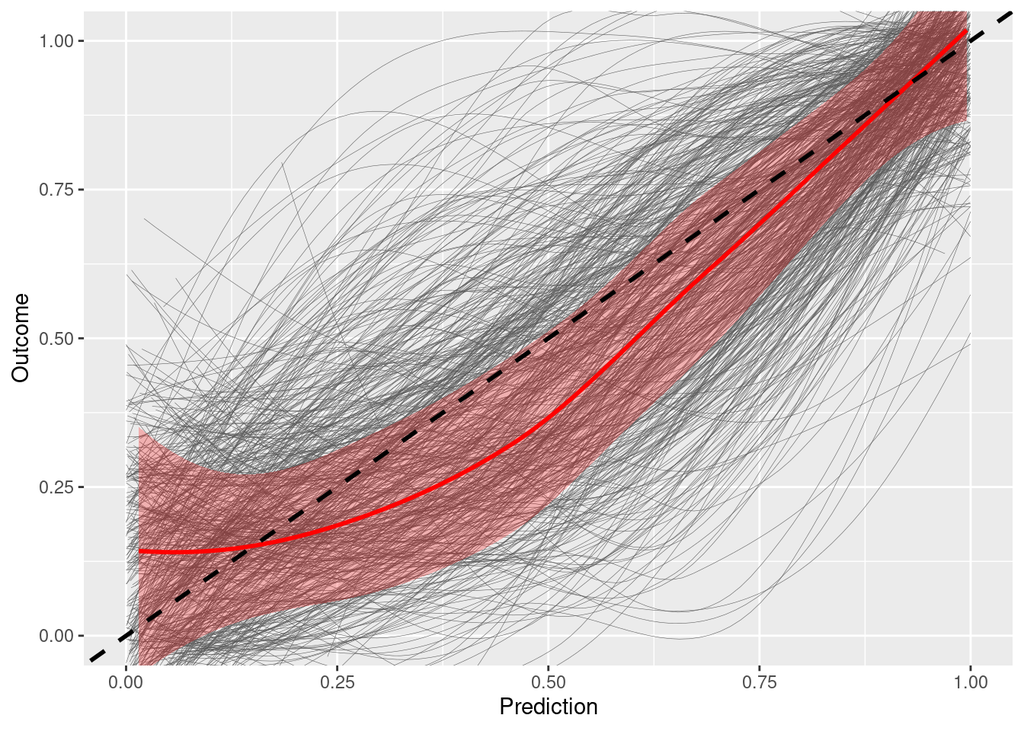

```r
## Prepare working data
dat_pred_temp <- dat_pred %>%
  filter(GRP != 'VG') %>%
  mutate(outcome = if_else(GRP == 'VN', 1, 0)) %>%
  select(-GRP)

mean(dat_pred_temp$outcome)
## [1] 0.5809524

## Fit and validate model
modelac <- 'pred_complet_child_all_VN_OM'

assign(modelac, run(
  clustered_glmnet(
    data = dat_pred_temp,
    outcome = 'outcome',
    clust_id = 'FAM',
    sample_method = 'atypboot',
    N = 500,
    alphas = seq(0, 1, by = 0.2),
    seed = 368),
  path = paste0('gitignore/run/', modelac),
  reuse = TRUE))

## Calibration curve
get(modelac)$plot
## `geom_smooth()` using formula = 'y ~ x'
## `geom_smooth()` using formula = 'y ~ x'
```

**Open code**

```r
## Model summary
t(get(modelac)$model_summary)
##                                      [,1]
## alpha                           0.2000000
## lambda                          0.0999577
## auc                             0.9828614
## auc_optimism_corrected          0.8646881
## auc_optimism_corrected_CIL      0.7430309
## auc_optimism_corrected_CIU      0.9522917
## accuracy                        0.9333333
## accuracy_optimism_corrected     0.7781709
## accuracy_optimism_corrected_CIL 0.6363991
## accuracy_optimism_corrected_CIU 0.9004756
get(modelac)$valid_performances %>% summary
##  auc_resamp_test  auc_resamp_validation  auc_optimism      accuracy_resamp_test
##  Min.   :0.9551   Min.   :0.6565        Min.   :-0.01226   Min.   :0.8796
##  1st Qu.:0.9943   1st Qu.:0.8333        1st Qu.: 0.09301   1st Qu.:0.9623
##  Median :0.9990   Median :0.8721        Median : 0.12419   Median :0.9811
##  Mean   :0.9957   Mean   :0.8647        Mean   : 0.13099   Mean   :0.9756
##  3rd Qu.:1.0000   3rd Qu.:0.9033        3rd Qu.: 0.16485   3rd Qu.:1.0000
##  Max.   :1.0000   Max.   :0.9931        Max.   : 0.34345   Max.   :1.0000
##  accuracy_resamp_validation accuracy_optimism
##  Min.   :0.5208             Min.   :-0.08761
##  1st Qu.:0.7368             1st Qu.: 0.14786
##  Median :0.7838             Median : 0.19982
##  Mean   :0.7782             Mean   : 0.19743
##  3rd Qu.:0.8235             3rd Qu.: 0.24390
##  Max.   :0.9722             Max.   : 0.47917

## Model coefficients
get(modelac)$betas
## 47 x 1 sparse Matrix of class "dgCMatrix"
##                                    s0
## log2_age                 -0.023259913
## male                      0.034639697
## BreastFeed_full_duration  .
## BreastFeed_full_stopped   .
## BreastFeed_total_stopped -0.187358974
## BiW                      -0.225673112
## MASS_Perc                -0.124980706
## HEIGHT_Perc              -0.352304701
## BMI_PERC                  .
## M_per_H_PERC              .
## GLY                       0.008439785
## TC                        .
## HDL                       0.037182485
## LDL                      -0.146417229
## Ca                        .
## P                         .
## Mg                        0.271171726
## FE                        .
## TIBC                     -0.213925698
## TRF                      -0.321646059
## SATTRF                    0.116861635
## HGB                      -0.139453747
## MCV                       0.652158784
## PTH                       0.129721503
## P1NP                      0.081592097
## UREA                     -0.258241015
## UA                       -0.029756305
## FOLATE                    0.856689101
## uPCR                     -1.103703323
## AL_child                 -0.140009893
## log2_TG                   .
## log2_Se                  -0.027280307
## log2_Zn                  -0.155872826
## log2_FERR                -0.665202312
## log2_TRFINDEX             0.250201535
## log2_STRF                 .
## log2_CTX                  .
## log2_UI                  -0.084845177
## log2_CREA                -0.372434731
## log2_HOLOTC               0.484119828
## log2_HCY                  .
## log2_MMA                 -0.953253014
## log2_VIT_D                0.392936461
## log2_IGF1                -0.355548896
## log2_uCa                 -0.023014066
## log2_uCCR                 .
## log2_uICR                 .
```

#### 3.1.2.3 VG vs OM

**Open code**

```r
## Prepare working data
dat_pred_temp <- dat_pred %>%
  filter(GRP != 'VN') %>%
  mutate(outcome = if_else(GRP == 'VG', 1, 0)) %>%
  select(-GRP)

mean(dat_pred_temp$outcome)
## [1] 0.4567901

## Fit and validate model
modelac <- 'pred_complet_child_all_VG_OM'

assign(modelac, run(
  clustered_glmnet(
    data = dat_pred_temp,
    outcome = 'outcome',
    clust_id = 'FAM',
    sample_method = 'atypboot',
    N = 500,
    alphas = seq(0, 1, by = 0.2),
    seed = 368),
  path = paste0('gitignore/run/', modelac),
  reuse = TRUE))

## Calibration curve
#get(modelac)$plot

## Model summary
t(get(modelac)$model_summary)
##                                      [,1]
## alpha                           0.6000000
## lambda                          0.1728403
## auc                             0.7979115
## auc_optimism_corrected          0.5908125
## auc_optimism_corrected_CIL      0.3239306
## auc_optimism_corrected_CIU      0.8460016
## accuracy                        0.7160494
## accuracy_optimism_corrected     0.5438350
## accuracy_optimism_corrected_CIL 0.3214286
## accuracy_optimism_corrected_CIU 0.7500000
get(modelac)$valid_performances %>% summary
##  auc_resamp_test  auc_resamp_validation  auc_optimism     accuracy_resamp_test
##  Min.   :0.5000   Min.   :0.2173        Min.   :-0.1640   Min.   :0.5658
##  1st Qu.:0.9085   1st Qu.:0.5048        1st Qu.: 0.2347   1st Qu.:0.8292
##  Median :0.9500   Median :0.5887        Median : 0.3690   Median :0.8902
##  Mean   :0.9385   Mean   :0.5908        Mean   : 0.3477   Mean   :0.8790
##  3rd Qu.:0.9845   3rd Qu.:0.6815        3rd Qu.: 0.4635   3rd Qu.:0.9452
##  Max.   :1.0000   Max.   :0.9667        Max.   : 0.7811   Max.   :1.0000
##  accuracy_resamp_validation accuracy_optimism
##  Min.   :0.1429             Min.   :-0.1357
##  1st Qu.:0.4682             1st Qu.: 0.2278
##  Median :0.5484             Median : 0.3466
##  Mean   :0.5438             Mean   : 0.3352
##  3rd Qu.:0.6167             3rd Qu.: 0.4450
##  Max.   :0.8750             Max.   : 0.8275

## Model coefficients
get(modelac)$betas
## 47 x 1 sparse Matrix of class "dgCMatrix"
##                                   s0
## log2_age                  .
## male                      .
## BreastFeed_full_duration  .
## BreastFeed_full_stopped   .
## BreastFeed_total_stopped  .
## BiW                       .
## MASS_Perc                 .
## HEIGHT_Perc               .
## BMI_PERC                  .
## M_per_H_PERC              .
## GLY                       .
## TC                        .
## HDL                       .
## LDL                       .
## Ca                        .
## P                         .
## Mg                        .
## FE                        .
## TIBC                      .
## TRF                       .
## SATTRF                    .
## HGB                       .
## MCV                       .
## PTH                       .
## P1NP                      .
## UREA                      .
## UA                        .
## FOLATE                    0.90209325
## uPCR                     -0.04462848
## AL_child                  .
## log2_TG                   .
## log2_Se                   .
## log2_Zn                   .
## log2_FERR                 .
## log2_TRFINDEX             .
## log2_STRF                 .
## log2_CTX                  .
## log2_UI                   .
## log2_CREA                 .
## log2_HOLOTC               .
## log2_HCY                  .
## log2_MMA                  .
## log2_VIT_D                .
## log2_IGF1                 .
## log2_uCa                  .
## log2_uCCR                 .
## log2_uICR                 .
```

#### 3.1.2.4 VN vs VG

**Open code**

```r
## Prepare working data
dat_pred_temp <- dat_pred %>%
  filter(GRP != 'OM') %>%
  mutate(outcome = if_else(GRP == 'VN', 1, 0)) %>%
  select(-GRP)

mean(dat_pred_temp$outcome)
## [1] 0.622449

## Fit and validate model
modelac <- 'pred_complet_child_all_VN_VG'

assign(modelac, run(
  clustered_glmnet(
    data = dat_pred_temp,
    outcome = 'outcome',
    clust_id = 'FAM',
    sample_method = 'atypboot',
    N = 500,
    alphas = seq(0, 1, by = 0.2),
    seed = 368),
  path = paste0('gitignore/run/', modelac),
  reuse = TRUE))

## Calibration curve
#get(modelac)$plot

## Model summary
t(get(modelac)$model_summary)
##                                       [,1]
## alpha                           1.00000000
## lambda                          0.05240856
## auc                             0.92822331
## auc_optimism_corrected          0.70426316
## auc_optimism_corrected_CIL      0.52312653
## auc_optimism_corrected_CIU      0.87598815
## accuracy                        0.80612245
## accuracy_optimism_corrected     0.66692062
## accuracy_optimism_corrected_CIL 0.50000000
## accuracy_optimism_corrected_CIU 0.81422697
get(modelac)$valid_performances %>% summary
##  auc_resamp_test  auc_resamp_validation  auc_optimism
##  Min.   :0.7897   Min.   :0.3720        Min.   :-0.002957
##  1st Qu.:0.9763   1st Qu.:0.6477        1st Qu.: 0.221844
##  Median :0.9915   Median :0.7097        Median : 0.275220
##  Mean   :0.9836   Mean   :0.7043        Mean   : 0.279333
##  3rd Qu.:0.9991   3rd Qu.:0.7622        3rd Qu.: 0.340465
##  Max.   :1.0000   Max.   :0.9592        Max.   : 0.607497
##  accuracy_resamp_test accuracy_resamp_validation accuracy_optimism
##  Min.   :0.6383       Min.   :0.3889             Min.   :-0.04508
##  1st Qu.:0.9164       1st Qu.:0.6130             1st Qu.: 0.21897
##  Median :0.9500       Median :0.6667             Median : 0.27420
##  Mean   :0.9419       Mean   :0.6669             Mean   : 0.27501
##  3rd Qu.:0.9796       3rd Qu.:0.7227             3rd Qu.: 0.33346
##  Max.   :1.0000       Max.   :0.9286             Max.   : 0.54862

## Model coefficients
get(modelac)$betas
## 47 x 1 sparse Matrix of class "dgCMatrix"
##                                   s0
## log2_age                 -0.37604128
## male                      .
## BreastFeed_full_duration  .
## BreastFeed_full_stopped   .
## BreastFeed_total_stopped  .
## BiW                       .
## MASS_Perc                 .
## HEIGHT_Perc              -0.42563039
## BMI_PERC                  .
## M_per_H_PERC              .
## GLY                       .
## TC                        .
## HDL                       0.02568811
## LDL                      -0.01840456
## Ca                        .
## P                         .
## Mg                        .
## FE                        .
## TIBC                      .
## TRF                       .
## SATTRF                    .
## HGB                       .
## MCV                       0.52833146
## PTH                       0.47085025
## P1NP                      .
## UREA                      .
## UA                        .
## FOLATE                    .
## uPCR                     -0.79802410
## AL_child                  .
## log2_TG                   0.02731084
## log2_Se                   .
## log2_Zn                   .
## log2_FERR                -0.06851785
## log2_TRFINDEX             0.30304989
## log2_STRF                 .
## log2_CTX                  .
## log2_UI                   .
## log2_CREA                 .
## log2_HOLOTC               0.75759266
## log2_HCY                  .
## log2_MMA                 -0.49930782
## log2_VIT_D                .
## log2_IGF1                -1.00932674
## log2_uCa                  .
## log2_uCCR                 .
## log2_uICR                 .
```

### 3.1.3 Reduced

Baseline + clinical characteristics not affected with vitamins supplementation

#### 3.1.3.1 Prepare data

**Open code**

```r
dat_pred <- dat_child_all_imputed %>%
  select(GRP, FAM, log2_age, male, BreastFeed_full_duration,
         BreastFeed_full_stopped, BreastFeed_total_stopped,
         BiW,
         MASS_Perc:Mg,
         log2_TG:log2_Zn,
         HGB:UA,
         log2_CTX, log2_CREA, log2_IGF1
         )

dat_features <- dat_pred %>% select(-FAM, -GRP)  %>% as.matrix
colnames(dat_features)
##  [1] "log2_age"                 "male"
##  [3] "BreastFeed_full_duration" "BreastFeed_full_stopped"
##  [5] "BreastFeed_total_stopped" "BiW"
##  [7] "MASS_Perc"                "HEIGHT_Perc"
##  [9] "BMI_PERC"                 "M_per_H_PERC"
## [11] "GLY"                      "TC"
## [13] "HDL"                      "LDL"
## [15] "Ca"                       "P"
## [17] "Mg"                       "log2_TG"
## [19] "log2_Se"                  "log2_Zn"
## [21] "HGB"                      "MCV"
## [23] "PTH"                      "P1NP"
## [25] "UREA"                     "UA"
## [27] "log2_CTX"                 "log2_CREA"
## [29] "log2_IGF1"
```

#### 3.1.3.2 VN vs OM

**Open code**

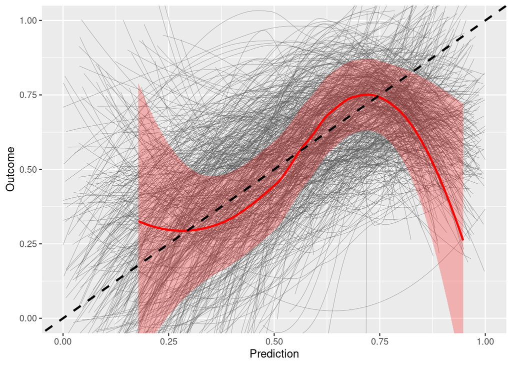

```r
## Prepare working data
dat_pred_temp <- dat_pred %>%
  filter(GRP != 'VG') %>%
  mutate(outcome = if_else(GRP == 'VN', 1, 0)) %>%
  select(-GRP)

mean(dat_pred_temp$outcome)
## [1] 0.5809524

## Fit and validate model
modelac <- 'pred_complex_child_all_VN_OM'

assign(modelac, run(
  clustered_glmnet(
    data = dat_pred_temp,
    outcome = 'outcome',
    clust_id = 'FAM',
    sample_method = 'atypboot',
    N = 500,
    alphas = seq(0, 1, by = 0.2),
    seed = 368),
  path = paste0('gitignore/run/', modelac),
  reuse = TRUE))

## Calibration curve
get(modelac)$plot
## `geom_smooth()` using formula = 'y ~ x'
## `geom_smooth()` using formula = 'y ~ x'
```

**Open code**

```r
## Model summary
t(get(modelac)$model_summary)
##                                      [,1]
## alpha                           0.0000000
## lambda                          0.6809560
## auc                             0.8386736
## auc_optimism_corrected          0.6525305
## auc_optimism_corrected_CIL      0.4571037
## auc_optimism_corrected_CIU      0.7993206
## accuracy                        0.7809524
## accuracy_optimism_corrected     0.6243409
## accuracy_optimism_corrected_CIL 0.4534091
## accuracy_optimism_corrected_CIU 0.7692308
get(modelac)$valid_performances %>% summary
##  auc_resamp_test  auc_resamp_validation  auc_optimism      accuracy_resamp_test
##  Min.   :0.5000   Min.   :0.2737        Min.   :-0.07665   Min.   :0.5701
##  1st Qu.:0.8850   1st Qu.:0.5949        1st Qu.: 0.17870   1st Qu.:0.8076
##  Median :0.9131   Median :0.6616        Median : 0.24716   Median :0.8500
##  Mean   :0.9089   Mean   :0.6525        Mean   : 0.25639   Mean   :0.8454
##  3rd Qu.:0.9421   3rd Qu.:0.7162        3rd Qu.: 0.33753   3rd Qu.:0.8879
##  Max.   :1.0000   Max.   :0.9261        Max.   : 0.64381   Max.   :1.0000
##  accuracy_resamp_validation accuracy_optimism
##  Min.   :0.3500             Min.   :-0.1079
##  1st Qu.:0.5714             1st Qu.: 0.1400
##  Median :0.6250             Median : 0.2216
##  Mean   :0.6243             Mean   : 0.2210
##  3rd Qu.:0.6832             3rd Qu.: 0.2973
##  Max.   :0.8649             Max.   : 0.5675

## Model coefficients
get(modelac)$betas
## 29 x 1 sparse Matrix of class "dgCMatrix"
##                                    s0
## log2_age                 -0.110371269
## male                      0.053478581
## BreastFeed_full_duration  0.106491593
## BreastFeed_full_stopped  -0.056983757
## BreastFeed_total_stopped -0.130809954
## BiW                      -0.062498656
## MASS_Perc                -0.137379843
## HEIGHT_Perc              -0.118087003
## BMI_PERC                 -0.044998977
## M_per_H_PERC             -0.049822380
## GLY                       0.010268256
## TC                       -0.111735304
## HDL                       0.025674988
## LDL                      -0.152029070
## Ca                       -0.008305915
## P                        -0.082862856
## Mg                        0.201323185
## log2_TG                   0.022002611
## log2_Se                  -0.045072287
## log2_Zn                  -0.132387542
## HGB                      -0.084029793
## MCV                       0.283508908
## PTH                       0.081431561
## P1NP                      0.138678669
## UREA                     -0.289097234
## UA                       -0.110530244
## log2_CTX                  0.097580361
## log2_CREA                -0.179034229
## log2_IGF1                -0.222260063
```

#### 3.1.3.3 VG vs OM

**Open code**

```r
## Prepare working data
dat_pred_temp <- dat_pred %>%
  filter(GRP != 'VN') %>%
  mutate(outcome = if_else(GRP == 'VG', 1, 0)) %>%
  select(-GRP)

mean(dat_pred_temp$outcome)
## [1] 0.4567901

## Fit and validate model
modelac <- 'pred_complex_child_all_VG_OM'

assign(modelac, run(
  clustered_glmnet(
    data = dat_pred_temp,
    outcome = 'outcome',
    clust_id = 'FAM',
    sample_method = 'atypboot',
    N = 500,
    alphas = seq(0, 1, by = 0.2),
    seed = 368),
  path = paste0('gitignore/run/', modelac),
  reuse = TRUE))

## Calibration curve
#get(modelac)$plot

## Model summary
t(get(modelac)$model_summary)
##                                      [,1]
## alpha                           0.6000000
## lambda                          0.1791455
## auc                             0.5000000
## auc_optimism_corrected          0.4245962
## auc_optimism_corrected_CIL      0.2087214
## auc_optimism_corrected_CIU      0.6402794
## accuracy                        0.5432099
## accuracy_optimism_corrected     0.4229261
## accuracy_optimism_corrected_CIL 0.2366246
## accuracy_optimism_corrected_CIU 0.5956818
get(modelac)$valid_performances %>% summary
##  auc_resamp_test  auc_resamp_validation  auc_optimism      accuracy_resamp_test
##  Min.   :0.5000   Min.   :0.1324        Min.   :-0.04312   Min.   :0.5057
##  1st Qu.:0.8268   1st Qu.:0.3550        1st Qu.: 0.36449   1st Qu.:0.7124
##  Median :0.8900   Median :0.4269        Median : 0.46237   Median :0.7975
##  Mean   :0.8636   Mean   :0.4246        Mean   : 0.43898   Mean   :0.7823
##  3rd Qu.:0.9376   3rd Qu.:0.5000        3rd Qu.: 0.54385   3rd Qu.:0.8593
##  Max.   :1.0000   Max.   :0.7273        Max.   : 0.79429   Max.   :1.0000
##  accuracy_resamp_validation accuracy_optimism
##  Min.   :0.1613             Min.   :-0.1658
##  1st Qu.:0.3585             1st Qu.: 0.2738
##  Median :0.4202             Median : 0.3767
##  Mean   :0.4229             Mean   : 0.3594
##  3rd Qu.:0.4839             3rd Qu.: 0.4559
##  Max.   :0.6786             Max.   : 0.7059

## Model coefficients
get(modelac)$betas
## 29 x 1 sparse Matrix of class "dgCMatrix"
##                          s0
## log2_age                  0
## male                      .
## BreastFeed_full_duration  .
## BreastFeed_full_stopped   .
## BreastFeed_total_stopped  .
## BiW                       .
## MASS_Perc                 .
## HEIGHT_Perc               .
## BMI_PERC                  .
## M_per_H_PERC              .
## GLY                       .
## TC                        .
## HDL                       .
## LDL                       .
## Ca                        .
## P                         .
## Mg                        .
## log2_TG                   .
## log2_Se                   .
## log2_Zn                   .
## HGB                       .
## MCV                       .
## PTH                       .
## P1NP                      .
## UREA                      .
## UA                        .
## log2_CTX                  .
## log2_CREA                 .
## log2_IGF1                 .
```

#### 3.1.3.4 VN vs VG

**Open code**

```r
## Prepare working data
dat_pred_temp <- dat_pred %>%
  filter(GRP != 'OM') %>%
  mutate(outcome = if_else(GRP == 'VN', 1, 0)) %>%
  select(-GRP)

mean(dat_pred_temp$outcome)
## [1] 0.622449

## Fit and validate model
modelac <- 'pred_complex_child_all_VN_VG'

assign(modelac, run(
  clustered_glmnet(
    data = dat_pred_temp,
    outcome = 'outcome',
    clust_id = 'FAM',
    sample_method = 'atypboot',
    N = 500,
    alphas = seq(0, 1, by = 0.2),
    seed = 368),
  path = paste0('gitignore/run/', modelac),
  reuse = TRUE))

## Calibration curve
#get(modelac)$plot

## Model summary
t(get(modelac)$model_summary)
##                                      [,1]
## alpha                           0.0000000
## lambda                          0.7235655
## auc                             0.8223305
## auc_optimism_corrected          0.6437341
## auc_optimism_corrected_CIL      0.4675493
## auc_optimism_corrected_CIU      0.7907643
## accuracy                        0.7142857
## accuracy_optimism_corrected     0.6341987
## accuracy_optimism_corrected_CIL 0.4736842
## accuracy_optimism_corrected_CIU 0.7765848
get(modelac)$valid_performances %>% summary
##  auc_resamp_test  auc_resamp_validation  auc_optimism     accuracy_resamp_test
##  Min.   :0.5000   Min.   :0.3273        Min.   :-0.0257   Min.   :0.6383
##  1st Qu.:0.8980   1st Qu.:0.5858        1st Qu.: 0.2044   1st Qu.:0.8122
##  Median :0.9283   Median :0.6504        Median : 0.2744   Median :0.8601
##  Mean   :0.9211   Mean   :0.6437        Mean   : 0.2774   Mean   :0.8538
##  3rd Qu.:0.9571   3rd Qu.:0.7053        3rd Qu.: 0.3508   3rd Qu.:0.9000
##  Max.   :1.0000   Max.   :0.8878        Max.   : 0.5962   Max.   :1.0000
##  accuracy_resamp_validation accuracy_optimism
##  Min.   :0.3889             Min.   :-0.06015
##  1st Qu.:0.5833             1st Qu.: 0.14928
##  Median :0.6389             Median : 0.22152
##  Mean   :0.6342             Mean   : 0.21961
##  3rd Qu.:0.6897             3rd Qu.: 0.29115
##  Max.   :0.8333             Max.   : 0.52632

## Model coefficients
get(modelac)$betas
## 29 x 1 sparse Matrix of class "dgCMatrix"
##                                    s0
## log2_age                 -0.150337798
## male                     -0.015480652
## BreastFeed_full_duration -0.040635603
## BreastFeed_full_stopped   0.205739460
## BreastFeed_total_stopped  0.009038895
## BiW                      -0.031318165
## MASS_Perc                -0.091286922
## HEIGHT_Perc              -0.162930580
## BMI_PERC                  0.012574086
## M_per_H_PERC              0.023907659
## GLY                       0.012894483
## TC                       -0.046958074
## HDL                       0.116489341
## LDL                      -0.205738166
## Ca                        0.025643757
## P                         0.018195206
## Mg                        0.011956604
## log2_TG                   0.234485157
## log2_Se                  -0.020382580
## log2_Zn                  -0.124665155
## HGB                      -0.116479185
## MCV                       0.240224485
## PTH                       0.215368558
## P1NP                      0.100360490
## UREA                     -0.141122560
## UA                       -0.036142120
## log2_CTX                  0.084311132
## log2_CREA                -0.148321250
## log2_IGF1                -0.217991779
```

## 3.2 Adults

### 3.2.1 Baseline model

Following models will be trained to discriminate between two diets, based solely on `AGE` and `SEX`.

#### 3.2.1.1 Prepare data

**Open code**

```r
dat_pred <- dat_adult_imputed %>%
  select(GRP, FAM, AGE, male)

nfam <- dat_pred$FAM %>% factor() %>% levels() %>% length()

dat_features <- dat_pred %>% select(-FAM, -GRP) %>% as.matrix
colnames(dat_features)
## [1] "AGE"  "male"

dat_outcome <- dat_pred %>% select(GRP) %>% as.matrix
```

#### 3.2.1.2 VN vs OM

**Open code**

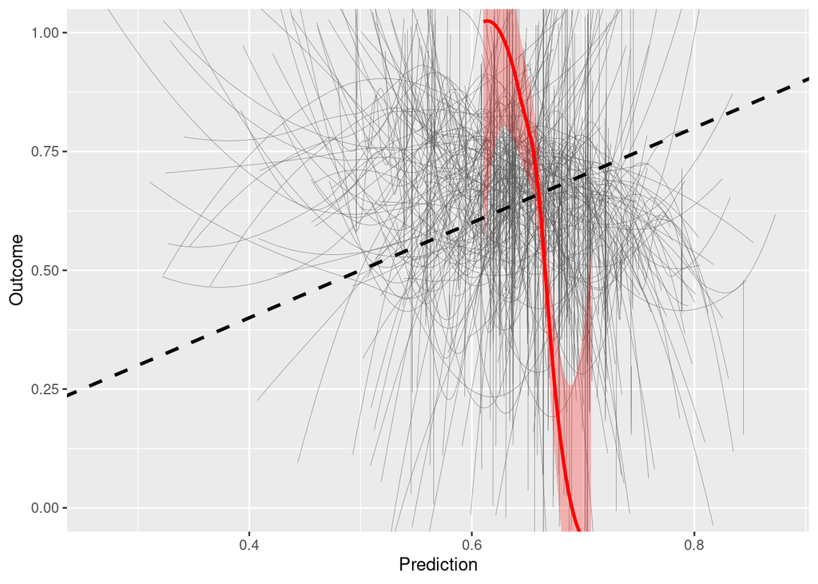

```r
## Prepare working data
dat_pred_temp <- dat_pred %>%
  filter(GRP != 'VG') %>%
  mutate(outcome = if_else(GRP == 'VN', 1, 0)) %>%
  select(-GRP)

mean(dat_pred_temp$outcome)
## [1] 0.6478873

## Fit and validate model
modelac <- 'pred_baseline_adult_VN_OM'

assign(modelac, run(
  clustered_glmnet(
    data = dat_pred_temp,
    outcome = 'outcome',
    clust_id = 'FAM',
    sample_method = 'atypboot',
    N = 500,
    alphas = seq(0, 1, by = 0.2),
    seed = 368),
  path = paste0('gitignore/run/', modelac),
  reuse = TRUE))

## Calibration curve
get(modelac)$plot
## `geom_smooth()` using formula = 'y ~ x'
## `geom_smooth()` using formula = 'y ~ x'
```

**Open code**

```r
## Model summary
t(get(modelac)$model_summary)
##                                      [,1]
## alpha                           0.2000000
## lambda                          0.4340878
## auc                             0.5000000
## auc_optimism_corrected          0.5423400
## auc_optimism_corrected_CIL      0.3829571
## auc_optimism_corrected_CIU      0.7098909
## accuracy                        0.6478873
## accuracy_optimism_corrected     0.6371038
## accuracy_optimism_corrected_CIL 0.4797907
## accuracy_optimism_corrected_CIU 0.7724352
get(modelac)$valid_performances %>% summary
##  auc_resamp_test  auc_resamp_validation  auc_optimism      accuracy_resamp_test
##  Min.   :0.4772   Min.   :0.2129        Min.   :-0.23936   Min.   :0.5035
##  1st Qu.:0.5000   1st Qu.:0.5000        1st Qu.: 0.00000   1st Qu.:0.6224
##  Median :0.5587   Median :0.5021        Median : 0.00000   Median :0.6572
##  Mean   :0.5774   Mean   :0.5423        Mean   : 0.03508   Mean   :0.6578
##  3rd Qu.:0.6479   3rd Qu.:0.5990        3rd Qu.: 0.09408   3rd Qu.:0.6901
##  Max.   :0.7760   Max.   :0.7733        Max.   : 0.38934   Max.   :0.8440
##  accuracy_resamp_validation accuracy_optimism
##  Min.   :0.1695             Min.   :-0.39192
##  1st Qu.:0.5889             1st Qu.:-0.06042
##  Median :0.6400             Median : 0.01420
##  Mean   :0.6371             Mean   : 0.02068
##  3rd Qu.:0.6897             3rd Qu.: 0.10019
##  Max.   :0.9130             Max.   : 0.43414

## Model coefficients
get(modelac)$betas
## 2 x 1 sparse Matrix of class "dgCMatrix"
##      s0
## AGE   0
## male  .
```

#### 3.2.1.3 VG vs OM

**Open code**

```r
## Prepare working data
dat_pred_temp <- dat_pred %>%
  filter(GRP != 'VN') %>%
  mutate(outcome = if_else(GRP == 'VG', 1, 0)) %>%
  select(-GRP)

mean(dat_pred_temp$outcome)
## [1] 0.4736842

## Fit and validate model
modelac <- 'pred_baseline_adult_VG_OM'

assign(modelac, run(
  clustered_glmnet(
    data = dat_pred_temp,
    outcome = 'outcome',
    clust_id = 'FAM',
    sample_method = 'atypboot',
    N = 500,
    alphas = seq(0, 1, by = 0.2),
    seed = 368),
  path = paste0('gitignore/run/', modelac),
  reuse = TRUE))

## Calibration curve
#get(modelac)$plot

## Model summary
t(get(modelac)$model_summary)
##                                       [,1]
## alpha                           0.60000000
## lambda                          0.01329009
## auc                             0.52333333
## auc_optimism_corrected          0.46703618
## auc_optimism_corrected_CIL      0.30289855
## auc_optimism_corrected_CIU      0.58972902
## accuracy                        0.52631579
## accuracy_optimism_corrected     0.45329487
## accuracy_optimism_corrected_CIL 0.26000000
## accuracy_optimism_corrected_CIU 0.62043269
get(modelac)$valid_performances %>% summary
##  auc_resamp_test  auc_resamp_validation  auc_optimism      accuracy_resamp_test
##  Min.   :0.4300   Min.   :0.1683        Min.   :-0.20455   Min.   :0.4167
##  1st Qu.:0.5000   1st Qu.:0.4294        1st Qu.: 0.00000   1st Qu.:0.5263
##  Median :0.5137   Median :0.5000        Median : 0.01497   Median :0.5579
##  Mean   :0.5332   Mean   :0.4670        Mean   : 0.06621   Mean   :0.5654
##  3rd Qu.:0.5586   3rd Qu.:0.5000        3rd Qu.: 0.12488   3rd Qu.:0.5895
##  Max.   :0.7344   Max.   :0.7151        Max.   : 0.52763   Max.   :0.7419
##  accuracy_resamp_validation accuracy_optimism
##  Min.   :0.1515             Min.   :-0.19443
##  1st Qu.:0.3889             1st Qu.: 0.02412
##  Median :0.4615             Median : 0.09530
##  Mean   :0.4533             Mean   : 0.11213
##  3rd Qu.:0.5238             3rd Qu.: 0.20063
##  Max.   :0.6897             Max.   : 0.55682

## Model coefficients
get(modelac)$betas
## 2 x 1 sparse Matrix of class "dgCMatrix"
##                s0
## AGE  -4.12632e-17
## male  .
```

#### 3.2.1.4 VN vs VG

**Open code**

```r
## Prepare working data
dat_pred_temp <- dat_pred %>%
  filter(GRP != 'OM') %>%
  mutate(outcome = if_else(GRP == 'VN', 1, 0)) %>%
  select(-GRP)

mean(dat_pred_temp$outcome)
## [1] 0.6715328

## Fit and validate model
modelac <- 'pred_baseline_adult_VN_VG'

assign(modelac, run(
  clustered_glmnet(
    data = dat_pred_temp,
    outcome = 'outcome',
    clust_id = 'FAM',
    sample_method = 'atypboot',
    N = 500,
    alphas = seq(0, 1, by = 0.2),
    seed = 368),
  path = paste0('gitignore/run/', modelac),
  reuse = TRUE))

## Calibration curve
#get(modelac)$plot

## Model summary
t(get(modelac)$model_summary)
##                                       [,1]
## alpha                           1.00000000
## lambda                          0.08085931
## auc                             0.50000000
## auc_optimism_corrected          0.54883991
## auc_optimism_corrected_CIL      0.40903409
## auc_optimism_corrected_CIU      0.73334865
## accuracy                        0.67153285
## accuracy_optimism_corrected     0.66674384
## accuracy_optimism_corrected_CIL 0.52882908
## accuracy_optimism_corrected_CIU 0.80701754
get(modelac)$valid_performances %>% summary
##  auc_resamp_test  auc_resamp_validation  auc_optimism      accuracy_resamp_test
##  Min.   :0.4699   Min.   :0.1779        Min.   :-0.29205   Min.   :0.5036
##  1st Qu.:0.5000   1st Qu.:0.5000        1st Qu.: 0.00000   1st Qu.:0.6350
##  Median :0.5385   Median :0.5167        Median : 0.00000   Median :0.6752
##  Mean   :0.5743   Mean   :0.5488        Mean   : 0.02549   Mean   :0.6728
##  3rd Qu.:0.6488   3rd Qu.:0.5996        3rd Qu.: 0.07911   3rd Qu.:0.7122
##  Max.   :0.7632   Max.   :0.8387        Max.   : 0.37786   Max.   :0.8406
##  accuracy_resamp_validation accuracy_optimism
##  Min.   :0.4048             Min.   :-0.353546
##  1st Qu.:0.6205             1st Qu.:-0.070669
##  Median :0.6604             Median : 0.012268
##  Mean   :0.6667             Mean   : 0.006068
##  3rd Qu.:0.7143             3rd Qu.: 0.085948
##  Max.   :0.8679             Max.   : 0.435818

## Model coefficients
get(modelac)$betas
## 2 x 1 sparse Matrix of class "dgCMatrix"
##      s0
## AGE   0
## male  .
```

### 3.2.2 Complete model

Baseline + clinical characteristics

#### 3.2.2.1 Prepare data

**Open code**

```r
dat_pred <- dat_adult_imputed

dat_features <- dat_pred %>% select(-FAM, -GRP)  %>% as.matrix
colnames(dat_features)
##  [1] "AGE"           "male"          "BMI"           "WHR"
##  [5] "HEIGHT"        "MASS"          "HG"            "PFAT"
##  [9] "SBP"           "DBP"           "GLY"           "HDL"
## [13] "LDL"           "Ca"            "P"             "Mg"
## [17] "FE"            "SATTRF"        "HGB"           "MCV"
## [21] "PTH"           "UA"            "FOLATE"        "uPCR"
## [25] "AL_adult"      "BREAKS"        "log2_FAT"      "log2_FFM"
## [29] "log2_TC"       "log2_TG"       "log2_Se"       "log2_Zn"
## [33] "log2_TIBC"     "log2_FERR"     "log2_TRF"      "log2_TRFINDEX"
## [37] "log2_STRF"     "log2_CTX"      "log2_P1NP"     "log2_UI"
## [41] "log2_UREA"     "log2_CREA"     "log2_HOLOTC"   "log2_HCY"
## [45] "log2_MMA"      "log2_VIT_D"    "log2_uCa"      "log2_uCCR"
## [49] "log2_uICR"
```

#### 3.2.2.2 VN vs OM

**Open code**

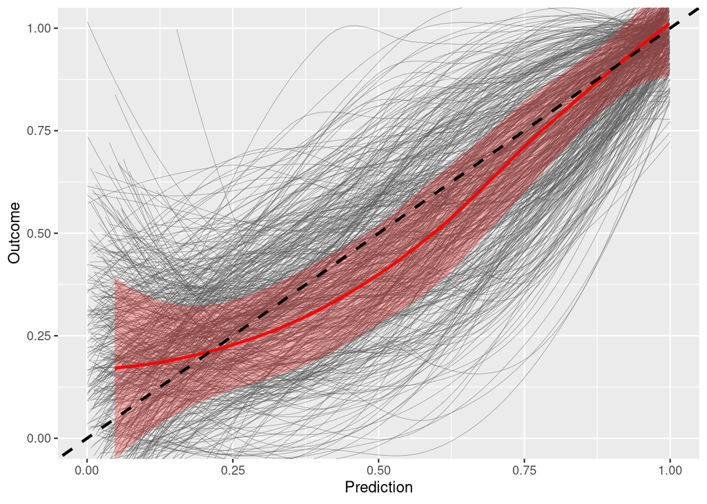

```r
## Prepare working data
dat_pred_temp <- dat_pred %>%
  filter(GRP != 'VG') %>%
  mutate(outcome = if_else(GRP == 'VN', 1, 0)) %>%
  select(-GRP)

mean(dat_pred_temp$outcome)
## [1] 0.6478873

## Fit and validate model
modelac <- 'pred_complet_adult_VN_OM'

assign(modelac, run(
  clustered_glmnet(
    data = dat_pred_temp,
    outcome = 'outcome',
    clust_id = 'FAM',
    sample_method = 'atypboot',
    N = 500,
    alphas = seq(0, 1, by = 0.2),
    seed = 368),
  path = paste0('gitignore/run/', modelac),
  reuse = TRUE))

## Calibration curve
get(modelac)$plot
## `geom_smooth()` using formula = 'y ~ x'
## `geom_smooth()` using formula = 'y ~ x'
```

**Open code**

```r
## Model summary
t(get(modelac)$model_summary)
##                                      [,1]
## alpha                           0.2000000
## lambda                          0.1200082
## auc                             0.9593478
## auc_optimism_corrected          0.8547846
## auc_optimism_corrected_CIL      0.7490948
## auc_optimism_corrected_CIU      0.9429849
## accuracy                        0.8943662
## accuracy_optimism_corrected     0.7744900
## accuracy_optimism_corrected_CIL 0.6525954
## accuracy_optimism_corrected_CIU 0.8800000
get(modelac)$valid_performances %>% summary
##  auc_resamp_test  auc_resamp_validation  auc_optimism
##  Min.   :0.9347   Min.   :0.6540        Min.   :-0.006052
##  1st Qu.:0.9844   1st Qu.:0.8242        1st Qu.: 0.097296
##  Median :0.9904   Median :0.8561        Median : 0.132035
##  Mean   :0.9890   Mean   :0.8548        Mean   : 0.134212
##  3rd Qu.:0.9960   3rd Qu.:0.8906        3rd Qu.: 0.170560
##  Max.   :1.0000   Max.   :0.9768        Max.   : 0.336612
##  accuracy_resamp_test accuracy_resamp_validation accuracy_optimism
##  Min.   :0.8462       Min.   :0.5690             Min.   :-0.0005417
##  1st Qu.:0.9429       1st Qu.:0.7358             1st Qu.: 0.1294366
##  Median :0.9577       Median :0.7757             Median : 0.1850655
##  Mean   :0.9559       Mean   :0.7745             Mean   : 0.1814488
##  3rd Qu.:0.9722       3rd Qu.:0.8148             3rd Qu.: 0.2275641
##  Max.   :1.0000       Max.   :0.9298             Max.   : 0.3817387

## Model coefficients
get(modelac)$betas
## 49 x 1 sparse Matrix of class "dgCMatrix"
##                        s0
## AGE           -0.03062496
## male           0.07229817
## BMI            .
## WHR            .
## HEIGHT         .
## MASS           .
## HG             0.10580374
## PFAT           .
## SBP            .
## DBP            .
## GLY           -0.23014855
## HDL            .
## LDL           -0.35487543
## Ca             0.06963822
## P             -0.23750534
## Mg             .
## FE             .
## SATTRF         .
## HGB            .
## MCV            0.20337668
## PTH            0.20244539
## UA             .
## FOLATE         0.59144460
## uPCR          -0.91171129
## AL_adult      -0.48157456
## BREAKS         .
## log2_FAT      -0.02620384
## log2_FFM       .
## log2_TC       -0.40941964
## log2_TG        .
## log2_Se       -0.17852882
## log2_Zn       -0.48824639
## log2_TIBC      .
## log2_FERR     -0.46820241
## log2_TRF       .
## log2_TRFINDEX  0.12147493
## log2_STRF      .
## log2_CTX       .
## log2_P1NP      0.37553616
## log2_UI       -0.18251390
## log2_UREA     -0.50687940
## log2_CREA     -0.41883894
## log2_HOLOTC    .
## log2_HCY       .
## log2_MMA       .
## log2_VIT_D     0.42509516
## log2_uCa      -0.01533056
## log2_uCCR     -0.14743311
## log2_uICR     -0.13191012
```

#### 3.2.2.3 VG vs OM

**Open code**

```r
## Prepare working data
dat_pred_temp <- dat_pred %>%
  filter(GRP != 'VN') %>%
  mutate(outcome = if_else(GRP == 'VG', 1, 0)) %>%
  select(-GRP)

mean(dat_pred_temp$outcome)
## [1] 0.4736842

## Fit and validate model
modelac <- 'pred_complet_adult_VG_OM'

assign(modelac, run(
  clustered_glmnet(
    data = dat_pred_temp,
    outcome = 'outcome',
    clust_id = 'FAM',
    sample_method = 'atypboot',
    N = 500,
    alphas = seq(0, 1, by = 0.2),
    seed = 368),
  path = paste0('gitignore/run/', modelac),
  reuse = TRUE))

## Calibration curve
#get(modelac)$plot

## Model summary
t(get(modelac)$model_summary)
##                                      [,1]
## alpha                           0.2000000
## lambda                          0.2626192
## auc                             0.8857778
## auc_optimism_corrected          0.6661926
## auc_optimism_corrected_CIL      0.4875733
## auc_optimism_corrected_CIU      0.8360262
## accuracy                        0.8315789
## accuracy_optimism_corrected     0.6081130
## accuracy_optimism_corrected_CIL 0.4201613
## accuracy_optimism_corrected_CIU 0.7670814
get(modelac)$valid_performances %>% summary
##  auc_resamp_test  auc_resamp_validation  auc_optimism      accuracy_resamp_test
##  Min.   :0.7145   Min.   :0.4091        Min.   :-0.05124   Min.   :0.5851
##  1st Qu.:0.9428   1st Qu.:0.6067        1st Qu.: 0.22871   1st Qu.:0.8737
##  Median :0.9696   Median :0.6685        Median : 0.30101   Median :0.9149
##  Mean   :0.9628   Mean   :0.6662        Mean   : 0.29657   Mean   :0.9075
##  3rd Qu.:0.9903   3rd Qu.:0.7274        3rd Qu.: 0.36386   3rd Qu.:0.9479
##  Max.   :1.0000   Max.   :0.9226        Max.   : 0.57402   Max.   :1.0000
##  accuracy_resamp_validation accuracy_optimism
##  Min.   :0.2917             Min.   :-0.1104
##  1st Qu.:0.5556             1st Qu.: 0.2307
##  Median :0.6154             Median : 0.2991
##  Mean   :0.6081             Mean   : 0.2994
##  3rd Qu.:0.6667             3rd Qu.: 0.3700
##  Max.   :0.8125             Max.   : 0.5715

## Model coefficients
get(modelac)$betas
## 49 x 1 sparse Matrix of class "dgCMatrix"
##                        s0
## AGE            .
## male           .
## BMI            .
## WHR            .
## HEIGHT         .
## MASS           .
## HG             .
## PFAT           .
## SBP            .
## DBP            0.01422657
## GLY            .
## HDL            .
## LDL            .
## Ca             .
## P              .
## Mg             .
## FE             .
## SATTRF         .
## HGB            .
## MCV           -0.01252481
## PTH            .
## UA             .
## FOLATE         0.44187862
## uPCR          -0.11239698
## AL_adult       .
## BREAKS         .
## log2_FAT       .
## log2_FFM       .
## log2_TC       -0.25571695
## log2_TG        .
## log2_Se       -0.20245555
## log2_Zn       -0.20792583
## log2_TIBC      .
## log2_FERR     -0.11934472
## log2_TRF       .
## log2_TRFINDEX  0.28357998
## log2_STRF      0.12923032
## log2_CTX       .
## log2_P1NP      .
## log2_UI       -0.31195970
## log2_UREA      .
## log2_CREA      .
## log2_HOLOTC   -0.20347552
## log2_HCY       0.02254704
## log2_MMA       0.25541403
## log2_VIT_D     0.01330014
## log2_uCa       .
## log2_uCCR      .
## log2_uICR     -0.37124364
```

#### 3.2.2.4 VN vs VG

**Open code**

```r
## Prepare working data
dat_pred_temp <- dat_pred %>%
  filter(GRP != 'OM') %>%
  mutate(outcome = if_else(GRP == 'VN', 1, 0)) %>%
  select(-GRP)


mean(dat_pred_temp$outcome)
## [1] 0.6715328

## Fit and validate model
modelac <- 'pred_complet_adult_VN_VG'

assign(modelac, run(
  clustered_glmnet(
    data = dat_pred_temp,
    outcome = 'outcome',
    clust_id = 'FAM',
    sample_method = 'atypboot',
    N = 500,
    alphas = seq(0, 1, by = 0.2),
    seed = 368),
  path = paste0('gitignore/run/', modelac),
  reuse = TRUE))

## Calibration curve
#get(modelac)$plot

## Model summary
t(get(modelac)$model_summary)
##                                      [,1]
## alpha                           0.6000000
## lambda                          0.1065992
## auc                             0.8246377
## auc_optimism_corrected          0.6567516
## auc_optimism_corrected_CIL      0.4814422
## auc_optimism_corrected_CIU      0.8026877
## accuracy                        0.6934307
## accuracy_optimism_corrected     0.6550346
## accuracy_optimism_corrected_CIL 0.5288291
## accuracy_optimism_corrected_CIU 0.7858469
get(modelac)$valid_performances %>% summary
##  auc_resamp_test  auc_resamp_validation  auc_optimism      accuracy_resamp_test
##  Min.   :0.5000   Min.   :0.2786        Min.   :-0.02315   Min.   :0.6496
##  1st Qu.:0.9106   1st Qu.:0.6135        1st Qu.: 0.21380   1st Qu.:0.8102
##  Median :0.9407   Median :0.6630        Median : 0.27586   Median :0.8540
##  Mean   :0.9337   Mean   :0.6568        Mean   : 0.27691   Mean   :0.8514
##  3rd Qu.:0.9633   3rd Qu.:0.7098        3rd Qu.: 0.33902   3rd Qu.:0.8972
##  Max.   :1.0000   Max.   :0.8824        Max.   : 0.70024   Max.   :1.0000
##  accuracy_resamp_validation accuracy_optimism
##  Min.   :0.4048             Min.   :-0.1458
##  1st Qu.:0.6087             1st Qu.: 0.1284
##  Median :0.6545             Median : 0.1922
##  Mean   :0.6550             Mean   : 0.1963
##  3rd Qu.:0.7000             3rd Qu.: 0.2608
##  Max.   :0.8333             Max.   : 0.5588

## Model coefficients
get(modelac)$betas
## 49 x 1 sparse Matrix of class "dgCMatrix"
##                          s0
## AGE            .
## male           .
## BMI            .
## WHR            .
## HEIGHT         .
## MASS           .
## HG             .
## PFAT           .
## SBP            .
## DBP           -0.4100252897
## GLY            .
## HDL            .
## LDL           -0.0298843600
## Ca             .
## P              .
## Mg             .
## FE             .
## SATTRF         .
## HGB            .
## MCV            0.1445031277
## PTH            0.3573358265
## UA             .
## FOLATE         .
## uPCR          -0.2804439274
## AL_adult      -0.1792452846
## BREAKS         .
## log2_FAT       .
## log2_FFM       .
## log2_TC        .
## log2_TG        .
## log2_Se        .
## log2_Zn        .
## log2_TIBC      .
## log2_FERR      .
## log2_TRF       .
## log2_TRFINDEX  .
## log2_STRF      .
## log2_CTX       .
## log2_P1NP      .
## log2_UI        .
## log2_UREA     -0.2367771870
## log2_CREA      .
## log2_HOLOTC    0.0791558791
## log2_HCY      -0.0009791532
## log2_MMA      -0.1251544859
## log2_VIT_D     .
## log2_uCa       .
## log2_uCCR      .
## log2_uICR      .
```

### 3.2.3 Reduced model

Baseline + clinical characteristics not affected with vitamin supplementation

#### 3.2.3.1 Prepare data

**Open code**

```r
dat_pred <- dat_adult_imputed %>%
  select(GRP, FAM, AGE, male,
         BMI:Mg,
         HGB:UA,
         AL_adult:log2_Zn,
         log2_CTX, log2_P1NP,
         log2_UREA:log2_CREA
         )

dat_features <- dat_pred %>% select(-FAM, -GRP)  %>% as.matrix
colnames(dat_features)
##  [1] "AGE"       "male"      "BMI"       "WHR"       "HEIGHT"    "MASS"
##  [7] "HG"        "PFAT"      "SBP"       "DBP"       "GLY"       "HDL"
## [13] "LDL"       "Ca"        "P"         "Mg"        "HGB"       "MCV"
## [19] "PTH"       "UA"        "AL_adult"  "BREAKS"    "log2_FAT"  "log2_FFM"
## [25] "log2_TC"   "log2_TG"   "log2_Se"   "log2_Zn"   "log2_CTX"  "log2_P1NP"
## [31] "log2_UREA" "log2_CREA"
```

#### 3.2.3.2 VN vs OM

**Open code**

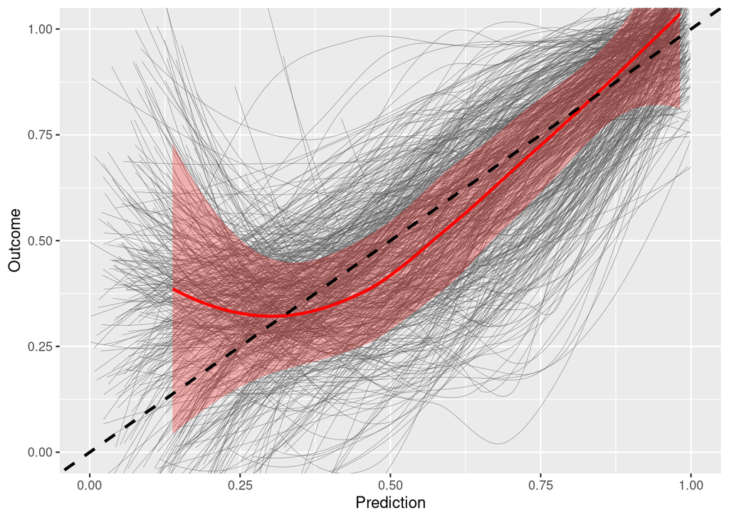

```r
## Prepare working data
dat_pred_temp <- dat_pred %>%
  filter(GRP != 'VG') %>%
  mutate(outcome = if_else(GRP == 'VN', 1, 0)) %>%
  select(-GRP)

mean(dat_pred_temp$outcome)
## [1] 0.6478873

## Fit and validate model
modelac <- 'pred_complex_adult_VN_OM'

assign(modelac, run(
  clustered_glmnet(
    data = dat_pred_temp,
    outcome = 'outcome',
    clust_id = 'FAM',
    sample_method = 'atypboot',
    N = 500,
    alphas = seq(0, 1, by = 0.2),
    seed = 368),
  path = paste0('gitignore/run/', modelac),
  reuse = TRUE))

## Calibration curve
get(modelac)$plot
## `geom_smooth()` using formula = 'y ~ x'
## `geom_smooth()` using formula = 'y ~ x'
```

**Open code**

```r
## Model summary
t(get(modelac)$model_summary)
##                                       [,1]
## alpha                           1.00000000
## lambda                          0.05634876
## auc                             0.87108696
## auc_optimism_corrected          0.78648076
## auc_optimism_corrected_CIL      0.67192971
## auc_optimism_corrected_CIU      0.89560516
## accuracy                        0.77464789
## accuracy_optimism_corrected     0.71226811
## accuracy_optimism_corrected_CIL 0.57883333
## accuracy_optimism_corrected_CIU 0.82352941
get(modelac)$valid_performances %>% summary
##  auc_resamp_test  auc_resamp_validation  auc_optimism      accuracy_resamp_test
##  Min.   :0.8386   Min.   :0.5562        Min.   :-0.05388   Min.   :0.7376
##  1st Qu.:0.9251   1st Qu.:0.7496        1st Qu.: 0.10153   1st Qu.:0.8389
##  Median :0.9403   Median :0.7892        Median : 0.14923   Median :0.8671
##  Mean   :0.9389   Mean   :0.7865        Mean   : 0.15240   Mean   :0.8661
##  3rd Qu.:0.9557   3rd Qu.:0.8286        3rd Qu.: 0.20162   3rd Qu.:0.8944
##  Max.   :1.0000   Max.   :0.9120        Max.   : 0.43843   Max.   :0.9930
##  accuracy_resamp_validation accuracy_optimism
##  Min.   :0.4694             Min.   :-0.08059
##  1st Qu.:0.6667             1st Qu.: 0.09333
##  Median :0.7177             Median : 0.15256
##  Mean   :0.7123             Mean   : 0.15384
##  3rd Qu.:0.7600             3rd Qu.: 0.21353
##  Max.   :0.8600             Max.   : 0.45925

## Model coefficients
get(modelac)$betas
## 32 x 1 sparse Matrix of class "dgCMatrix"
##                   s0
## AGE        .
## male       .
## BMI        .
## WHR        .
## HEIGHT     .
## MASS       .
## HG         .
## PFAT       .
## SBP        .
## DBP        .
## GLY        .
## HDL        .
## LDL        .
## Ca         .
## P          .
## Mg         .
## HGB        .
## MCV        .
## PTH        .
## UA         .
## AL_adult  -0.5110666
## BREAKS     .
## log2_FAT   .
## log2_FFM   .
## log2_TC   -1.0544345
## log2_TG    .
## log2_Se    .
## log2_Zn   -0.5595906
## log2_CTX   .
## log2_P1NP  0.3181682
## log2_UREA -0.9464709
## log2_CREA -0.1149042
```

#### 3.2.3.3 VG vs OM

**Open code**

```r
## Prepare working data
dat_pred_temp <- dat_pred %>%
  filter(GRP != 'VN') %>%
  mutate(outcome = if_else(GRP == 'VG', 1, 0)) %>%
  select(-GRP)

mean(dat_pred_temp$outcome)
## [1] 0.4736842

## Fit and validate model
modelac <- 'pred_complex_adult_VG_OM'

assign(modelac, run(
  clustered_glmnet(
    data = dat_pred_temp,
    outcome = 'outcome',
    clust_id = 'FAM',
    sample_method = 'atypboot',
    N = 500,
    alphas = seq(0, 1, by = 0.2),
    seed = 368),
  path = paste0('gitignore/run/', modelac),
  reuse = TRUE))

## Calibration curve
#get(modelac)$plot

## Model summary
t(get(modelac)$model_summary)
##                                      [,1]
## alpha                           0.2000000
## lambda                          0.6355181
## auc                             0.5000000
## auc_optimism_corrected          0.5050453
## auc_optimism_corrected_CIL      0.3253598
## auc_optimism_corrected_CIU      0.6672917
## accuracy                        0.5263158
## accuracy_optimism_corrected     0.4761204
## accuracy_optimism_corrected_CIL 0.2872222
## accuracy_optimism_corrected_CIU 0.6461575
get(modelac)$valid_performances %>% summary
##  auc_resamp_test  auc_resamp_validation  auc_optimism     accuracy_resamp_test
##  Min.   :0.5000   Min.   :0.2125        Min.   :-0.1105   Min.   :0.5106
##  1st Qu.:0.7939   1st Qu.:0.4512        1st Qu.: 0.2456   1st Qu.:0.6915
##  Median :0.8621   Median :0.5064        Median : 0.3411   Median :0.7696
##  Mean   :0.8357   Mean   :0.5050        Mean   : 0.3306   Mean   :0.7549
##  3rd Qu.:0.9027   3rd Qu.:0.5663        3rd Qu.: 0.4427   3rd Qu.:0.8316
##  Max.   :1.0000   Max.   :0.7593        Max.   : 0.7040   Max.   :1.0000
##  accuracy_resamp_validation accuracy_optimism
##  Min.   :0.1250             Min.   :-0.1480
##  1st Qu.:0.4133             1st Qu.: 0.1940
##  Median :0.4848             Median : 0.2881
##  Mean   :0.4761             Mean   : 0.2788
##  3rd Qu.:0.5385             3rd Qu.: 0.3761
##  Max.   :0.7059             Max.   : 0.6260

## Model coefficients
get(modelac)$betas
## 32 x 1 sparse Matrix of class "dgCMatrix"
##           s0
## AGE        0
## male       .
## BMI        .
## WHR        .
## HEIGHT     .
## MASS       .
## HG         .
## PFAT       .
## SBP        .
## DBP        .
## GLY        .
## HDL        .
## LDL        .
## Ca         .
## P          .
## Mg         .
## HGB        .
## MCV        .
## PTH        .
## UA         .
## AL_adult   .
## BREAKS     .
## log2_FAT   .
## log2_FFM   .
## log2_TC    .
## log2_TG    .
## log2_Se    .
## log2_Zn    .
## log2_CTX   .
## log2_P1NP  .
## log2_UREA  .
## log2_CREA  .
```

#### 3.2.3.4 VN vs VG

**Open code**

```r
## Prepare working data
dat_pred_temp <- dat_pred %>%
  filter(GRP != 'OM') %>%
  mutate(outcome = if_else(GRP == 'VN', 1, 0)) %>%
  select(-GRP)


mean(dat_pred_temp$outcome)
## [1] 0.6715328

## Fit and validate model
modelac <- 'pred_complex_adult_VN_VG'

assign(modelac, run(
  clustered_glmnet(
    data = dat_pred_temp,
    outcome = 'outcome',
    clust_id = 'FAM',
    sample_method = 'atypboot',
    N = 500,
    alphas = seq(0, 1, by = 0.2),
    seed = 368),
  path = paste0('gitignore/run/', modelac),
  reuse = TRUE))

## Calibration curve
#get(modelac)$plot

## Model summary
t(get(modelac)$model_summary)
##                                      [,1]
## alpha                           0.0000000
## lambda                          0.7353789
## auc                             0.8140097
## auc_optimism_corrected          0.6556023
## auc_optimism_corrected_CIL      0.4932692
## auc_optimism_corrected_CIU      0.7907299
## accuracy                        0.7080292
## accuracy_optimism_corrected     0.6500979
## accuracy_optimism_corrected_CIL 0.5185185
## accuracy_optimism_corrected_CIU 0.7659574
get(modelac)$valid_performances %>% summary
##  auc_resamp_test  auc_resamp_validation  auc_optimism      accuracy_resamp_test
##  Min.   :0.5000   Min.   :0.3782        Min.   :-0.03536   Min.   :0.6475
##  1st Qu.:0.8682   1st Qu.:0.6118        1st Qu.: 0.17729   1st Qu.:0.7704
##  Median :0.9001   Median :0.6599        Median : 0.23573   Median :0.8058
##  Mean   :0.8931   Mean   :0.6556        Mean   : 0.23749   Mean   :0.8074
##  3rd Qu.:0.9261   3rd Qu.:0.7059        3rd Qu.: 0.29642   3rd Qu.:0.8456
##  Max.   :0.9897   Max.   :0.8633        Max.   : 0.58373   Max.   :0.9485
##  accuracy_resamp_validation accuracy_optimism
##  Min.   :0.4048             Min.   :-0.08852
##  1st Qu.:0.6042             1st Qu.: 0.09059
##  Median :0.6522             Median : 0.14748
##  Mean   :0.6501             Mean   : 0.15732
##  3rd Qu.:0.6949             3rd Qu.: 0.21683
##  Max.   :0.8077             Max.   : 0.46158

## Model coefficients
get(modelac)$betas
## 32 x 1 sparse Matrix of class "dgCMatrix"
##                     s0
## AGE       -0.130969640
## male       0.046847677
## BMI       -0.025892148
## WHR       -0.071845276
## HEIGHT    -0.057146386
## MASS      -0.052079055
## HG         0.018645667
## PFAT      -0.072209270
## SBP        0.025161999
## DBP       -0.218387885
## GLY       -0.054679974
## HDL        0.007689509
## LDL       -0.110257424
## Ca         0.016184827
## P         -0.086481596
## Mg         0.011665361
## HGB        0.007370975
## MCV        0.179203214
## PTH        0.210230420
## UA         0.057920958
## AL_adult  -0.204033621
## BREAKS    -0.084629183
## log2_FAT  -0.065394397
## log2_FFM  -0.007507923
## log2_TC   -0.078258475
## log2_TG    0.017640442
## log2_Se    0.003677581
## log2_Zn   -0.139279629
## log2_CTX   0.105505924
## log2_P1NP  0.094490749
## log2_UREA -0.199522992
## log2_CREA -0.078104681
```